# Student 3000 Criminal Data

5조 강준호,권우민,임일화, 김지연

2016-05-31

## Structure of Data

### Data Manipulation

•W. S. Gosset 이 t-분포를 유도하느라고 모의실험에 활용한 자료는 다음과 같음. ◦table은 본질적으로 matrix임. 행과 열의 이름에 측정값을 글자로 새겨 넣었기 때문에 long format으로 변환할 때 많은 주의가 필요함.

```
##      142.24 144.78 147.32 149.86 152.4 154.94 157.48 160.02 162.56 165.1
## 9.4       0      0      0      0     0      0      0      0      0     0
## 9.5       0      0      0      0     0      1      0      0      0     0
## 9.6       0      0      0      0     0      0      0      0      0     0
## 9.7       0      0      0      0     0      0      0      0      0     0
## 9.8       0      0      0      0     0      0      1      0      0     0
## 9.9       0      0      1      0     1      0      1      0      0     0
## 10        1      0      0      1     2      0      2      0      0     1
## 10.1      0      0      0      1     3      1      0      1      1     0
## 10.2      0      0      2      2     2      1      0      2      0     1
## 10.3      0      1      1      3     2      2      3      5      0     0
## 10.4      0      0      1      1     2      3      3      4      3     3
## 10.5      0      0      0      1     3      7      6      4      3     1
## 10.6      0      0      0      1     4      5      9     14      6     3
## 10.7      0      0      1      2     4      9     14     16     15     7
## 10.8      0      0      0      2     5      6     14     27     10     7
## 10.9      0      0      0      0     2      6     14     24     27    14
## 11        0      0      0      2     6     12     15     31     37    27
## 11.1      0      0      0      3     3     12     22     26     24    26
## 11.2      0      0      0      3     2      7     21     30     38    29
## 11.3      0      0      0      1     0      5     10     24     26    39
## 11.4      0      0      0      0     3      4      9     29     56    58
## 11.5      0      0      0      0     0      5     11     17     33    57
## 11.6      0      0      0      0     2      1      4     13     37    39
## 11.7      0      0      0      0     0      2      9     17     30    37
## 11.8      0      0      0      0     1      0      2     11     15    35
## 11.9      0      0      0      0     1      1      2     12     10    27
## 12        0      0      0      0     0      0      1      4      8    19
## 12.1      0      0      0      0     0      0      0      2      4    13
## 12.2      0      0      0      0     0      0      1      2      5     6
## 12.3      0      0      0      0     0      0      0      0      4     8
## 12.4      0      0      0      0     0      0      1      1      1     2
## 12.5      0      0      0      0     0      0      0      1      0     1
## 12.6      0      0      0      0     0      0      0      0      0     1
## 12.7      0      0      0      0     0      0      0      0      0     1
## 12.8      0      0      0      0     0      0      0      0      0     0
## 12.9      0      0      0      0     0      0      0      0      0     0
## 13        0      0      0      0     0      0      0      0      0     0
## 13.1      0      0      0      0     0      0      0      0      0     0
## 13.2      0      0      0      0     0      0      0      0      0     0
```

[output cut: 74 more lines]

```
## 12.1      0      0
## 12.2      0      0
## 12.3      0      0
## 12.4      0      0
## 12.5      0      0
## 12.6      0      0
## 12.7      0      0
## 12.8      0      0
## 12.9      0      0
## 13        0      0
## 13.1      0      0
## 13.2      0      0
## 13.3      0      0
## 13.4      0      0
## 13.5      0      0
```

```
##  'table' int [1:42, 1:22] 0 0 0 0 0 0 1 0 0 0 ...
##  - attr(*, "dimnames")=List of 2
##   ..$ : chr [1:42] "9.4" "9.5" "9.6" "9.7" ...
##   ..$ : chr [1:22] "142.24" "144.78" "147.32" "149.86" ...
```

Gosset 자료를 표로 정리함.

```r
kable(crimtab)
```

|  | 142.24 | 144.78 | 147.32 | 149.86 | 152.4 | 154.94 | 157.48 | 160.02 | 162.56 | 165.1 | 167.64 | 170.18 | 172.72 | 175.26 | 177.8 | 180.34 | 182.88 | 185.42 | 187.96 | 190.5 | 193.04 | 195.58 |
| --- | --- | --- | --- | --- | --- | --- | --- | --- | --- | --- | --- | --- | --- | --- | --- | --- | --- | --- | --- | --- | --- | --- |
| 9.4 | 0 | 0 | 0 | 0 | 0 | 0 | 0 | 0 | 0 | 0 | 0 | 0 | 0 | 0 | 0 | 0 | 0 | 0 | 0 | 0 | 0 | 0 |
| 9.5 | 0 | 0 | 0 | 0 | 0 | 1 | 0 | 0 | 0 | 0 | 0 | 0 | 0 | 0 | 0 | 0 | 0 | 0 | 0 | 0 | 0 | 0 |
| 9.6 | 0 | 0 | 0 | 0 | 0 | 0 | 0 | 0 | 0 | 0 | 0 | 0 | 0 | 0 | 0 | 0 | 0 | 0 | 0 | 0 | 0 | 0 |
| 9.7 | 0 | 0 | 0 | 0 | 0 | 0 | 0 | 0 | 0 | 0 | 0 | 0 | 0 | 0 | 0 | 0 | 0 | 0 | 0 | 0 | 0 | 0 |
| 9.8 | 0 | 0 | 0 | 0 | 0 | 0 | 1 | 0 | 0 | 0 | 0 | 0 | 0 | 0 | 0 | 0 | 0 | 0 | 0 | 0 | 0 | 0 |
| 9.9 | 0 | 0 | 1 | 0 | 1 | 0 | 1 | 0 | 0 | 0 | 0 | 0 | 0 | 0 | 0 | 0 | 0 | 0 | 0 | 0 | 0 | 0 |
| 10 | 1 | 0 | 0 | 1 | 2 | 0 | 2 | 0 | 0 | 1 | 0 | 0 | 0 | 0 | 0 | 0 | 0 | 0 | 0 | 0 | 0 | 0 |
| 10.1 | 0 | 0 | 0 | 1 | 3 | 1 | 0 | 1 | 1 | 0 | 0 | 0 | 0 | 0 | 0 | 0 | 0 | 0 | 0 | 0 | 0 | 0 |
| 10.2 | 0 | 0 | 2 | 2 | 2 | 1 | 0 | 2 | 0 | 1 | 0 | 0 | 0 | 0 | 0 | 0 | 0 | 0 | 0 | 0 | 0 | 0 |
| 10.3 | 0 | 1 | 1 | 3 | 2 | 2 | 3 | 5 | 0 | 0 | 0 | 0 | 0 | 0 | 0 | 0 | 0 | 0 | 0 | 0 | 0 | 0 |
| 10.4 | 0 | 0 | 1 | 1 | 2 | 3 | 3 | 4 | 3 | 3 | 0 | 0 | 0 | 0 | 0 | 0 | 0 | 0 | 0 | 0 | 0 | 0 |
| 10.5 | 0 | 0 | 0 | 1 | 3 | 7 | 6 | 4 | 3 | 1 | 3 | 1 | 0 | 1 | 0 | 0 | 0 | 0 | 0 | 0 | 0 | 0 |
| 10.6 | 0 | 0 | 0 | 1 | 4 | 5 | 9 | 14 | 6 | 3 | 1 | 0 | 0 | 1 | 0 | 0 | 0 | 0 | 0 | 0 | 0 | 0 |
| 10.7 | 0 | 0 | 1 | 2 | 4 | 9 | 14 | 16 | 15 | 7 | 3 | 1 | 2 | 0 | 0 | 0 | 0 | 0 | 0 | 0 | 0 | 0 |
| 10.8 | 0 | 0 | 0 | 2 | 5 | 6 | 14 | 27 | 10 | 7 | 1 | 2 | 1 | 0 | 0 | 0 | 0 | 0 | 0 | 0 | 0 | 0 |
| 10.9 | 0 | 0 | 0 | 0 | 2 | 6 | 14 | 24 | 27 | 14 | 10 | 4 | 1 | 0 | 0 | 0 | 0 | 0 | 0 | 0 | 0 | 0 |
| 11 | 0 | 0 | 0 | 2 | 6 | 12 | 15 | 31 | 37 | 27 | 17 | 10 | 6 | 0 | 0 | 0 | 0 | 0 | 0 | 0 | 0 | 0 |
| 11.1 | 0 | 0 | 0 | 3 | 3 | 12 | 22 | 26 | 24 | 26 | 24 | 7 | 4 | 1 | 0 | 0 | 0 | 0 | 0 | 0 | 0 | 0 |
| 11.2 | 0 | 0 | 0 | 3 | 2 | 7 | 21 | 30 | 38 | 29 | 27 | 20 | 4 | 1 | 0 | 0 | 0 | 0 | 0 | 0 | 0 | 1 |
| 11.3 | 0 | 0 | 0 | 1 | 0 | 5 | 10 | 24 | 26 | 39 | 26 | 24 | 7 | 2 | 0 | 0 | 0 | 0 | 0 | 0 | 0 | 0 |
| 11.4 | 0 | 0 | 0 | 0 | 3 | 4 | 9 | 29 | 56 | 58 | 26 | 22 | 10 | 11 | 0 | 0 | 0 | 0 | 0 | 0 | 0 | 0 |
| 11.5 | 0 | 0 | 0 | 0 | 0 | 5 | 11 | 17 | 33 | 57 | 38 | 34 | 25 | 11 | 2 | 0 | 0 | 0 | 0 | 0 | 0 | 0 |
| 11.6 | 0 | 0 | 0 | 0 | 2 | 1 | 4 | 13 | 37 | 39 | 48 | 38 | 27 | 12 | 2 | 2 | 0 | 1 | 0 | 0 | 0 | 0 |
| 11.7 | 0 | 0 | 0 | 0 | 0 | 2 | 9 | 17 | 30 | 37 | 48 | 45 | 24 | 9 | 9 | 2 | 0 | 0 | 0 | 0 | 0 | 0 |
| 11.8 | 0 | 0 | 0 | 0 | 1 | 0 | 2 | 11 | 15 | 35 | 41 | 34 | 29 | 10 | 5 | 1 | 0 | 0 | 0 | 0 | 0 | 0 |
| 11.9 | 0 | 0 | 0 | 0 | 1 | 1 | 2 | 12 | 10 | 27 | 32 | 35 | 19 | 10 | 9 | 3 | 1 | 0 | 0 | 0 | 0 | 0 |
| 12 | 0 | 0 | 0 | 0 | 0 | 0 | 1 | 4 | 8 | 19 | 42 | 39 | 22 | 16 | 8 | 2 | 2 | 0 | 0 | 0 | 0 | 0 |
| 12.1 | 0 | 0 | 0 | 0 | 0 | 0 | 0 | 2 | 4 | 13 | 22 | 28 | 15 | 27 | 10 | 4 | 1 | 0 | 0 | 0 | 0 | 0 |
| 12.2 | 0 | 0 | 0 | 0 | 0 | 0 | 1 | 2 | 5 | 6 | 23 | 17 | 16 | 11 | 8 | 1 | 1 | 0 | 0 | 0 | 0 | 0 |
| 12.3 | 0 | 0 | 0 | 0 | 0 | 0 | 0 | 0 | 4 | 8 | 10 | 13 | 20 | 23 | 6 | 5 | 0 | 0 | 0 | 0 | 0 | 0 |
| 12.4 | 0 | 0 | 0 | 0 | 0 | 0 | 1 | 1 | 1 | 2 | 7 | 12 | 4 | 7 | 7 | 1 | 0 | 0 | 1 | 0 | 0 | 0 |
| 12.5 | 0 | 0 | 0 | 0 | 0 | 0 | 0 | 1 | 0 | 1 | 3 | 12 | 11 | 8 | 6 | 8 | 0 | 2 | 0 | 0 | 0 | 0 |
| 12.6 | 0 | 0 | 0 | 0 | 0 | 0 | 0 | 0 | 0 | 1 | 0 | 3 | 5 | 7 | 8 | 6 | 3 | 1 | 1 | 0 | 0 | 0 |
| 12.7 | 0 | 0 | 0 | 0 | 0 | 0 | 0 | 0 | 0 | 1 | 1 | 7 | 5 | 5 | 8 | 2 | 2 | 0 | 0 | 0 | 0 | 0 |
| 12.8 | 0 | 0 | 0 | 0 | 0 | 0 | 0 | 0 | 0 | 0 | 1 | 2 | 3 | 1 | 8 | 5 | 3 | 1 | 1 | 0 | 0 | 0 |
| 12.9 | 0 | 0 | 0 | 0 | 0 | 0 | 0 | 0 | 0 | 0 | 0 | 1 | 2 | 2 | 0 | 1 | 1 | 0 | 0 | 0 | 0 | 0 |
| 13 | 0 | 0 | 0 | 0 | 0 | 0 | 0 | 0 | 0 | 0 | 3 | 0 | 1 | 0 | 1 | 0 | 2 | 1 | 0 | 0 | 0 | 0 |
| 13.1 | 0 | 0 | 0 | 0 | 0 | 0 | 0 | 0 | 0 | 0 | 0 | 1 | 1 | 0 | 0 | 0 | 0 | 0 | 0 | 0 | 0 | 0 |
| 13.2 | 0 | 0 | 0 | 0 | 0 | 0 | 0 | 0 | 0 | 0 | 1 | 1 | 0 | 1 | 0 | 3 | 0 | 0 | 0 | 0 | 0 | 0 |
| 13.3 | 0 | 0 | 0 | 0 | 0 | 0 | 0 | 0 | 0 | 0 | 0 | 0 | 0 | 0 | 0 | 0 | 1 | 0 | 1 | 0 | 0 | 0 |
| 13.4 | 0 | 0 | 0 | 0 | 0 | 0 | 0 | 0 | 0 | 0 | 0 | 0 | 0 | 0 | 0 | 0 | 0 | 0 | 0 | 0 | 0 | 0 |
| 13.5 | 0 | 0 | 0 | 0 | 0 | 0 | 0 | 0 | 0 | 0 | 0 | 0 | 0 | 0 | 0 | 0 | 0 | 1 | 0 | 0 | 0 | 0 |

- 이러한 table 구조의 행과 열에 이름을 붙이려면, list로 부여 ◦cm 단위로 되어 있는 키의 계급을 인치 단위로 변환하면 숨어있던 자료구조다 드러남.

```r
dimnames(crimtab)
```

```
## [[1]]
##  [1] "9.4"  "9.5"  "9.6"  "9.7"  "9.8"  "9.9"  "10"   "10.1" "10.2" "10.3"
## [11] "10.4" "10.5" "10.6" "10.7" "10.8" "10.9" "11"   "11.1" "11.2" "11.3"
## [21] "11.4" "11.5" "11.6" "11.7" "11.8" "11.9" "12"   "12.1" "12.2" "12.3"
## [31] "12.4" "12.5" "12.6" "12.7" "12.8" "12.9" "13"   "13.1" "13.2" "13.3"
## [41] "13.4" "13.5"
##
## [[2]]
##  [1] "142.24" "144.78" "147.32" "149.86" "152.4"  "154.94" "157.48"
##  [8] "160.02" "162.56" "165.1"  "167.64" "170.18" "172.72" "175.26"
## [15] "177.8"  "180.34" "182.88" "185.42" "187.96" "190.5"  "193.04"
## [22] "195.58"
```

```r
crimtab.2 <- crimtab
colnames(crimtab.2) <- as.numeric(colnames(crimtab.2))/2.54
(dimnames(crimtab.2) <- list(finger = rownames(crimtab.2), height = colnames(crimtab.2)))
```

```
## $finger
##  [1] "9.4"  "9.5"  "9.6"  "9.7"  "9.8"  "9.9"  "10"   "10.1" "10.2" "10.3"
## [11] "10.4" "10.5" "10.6" "10.7" "10.8" "10.9" "11"   "11.1" "11.2" "11.3"
## [21] "11.4" "11.5" "11.6" "11.7" "11.8" "11.9" "12"   "12.1" "12.2" "12.3"
## [31] "12.4" "12.5" "12.6" "12.7" "12.8" "12.9" "13"   "13.1" "13.2" "13.3"
## [41] "13.4" "13.5"
##
## $height
##  [1] "56" "57" "58" "59" "60" "61" "62" "63" "64" "65" "66" "67" "68" "69"
## [15] "70" "71" "72" "73" "74" "75" "76" "77"
```

```r
crimtab.2
```

```
##       height
## finger 56 57 58 59 60 61 62 63 64 65 66 67 68 69 70 71 72 73 74 75 76 77
##   9.4   0  0  0  0  0  0  0  0  0  0  0  0  0  0  0  0  0  0  0  0  0  0
##   9.5   0  0  0  0  0  1  0  0  0  0  0  0  0  0  0  0  0  0  0  0  0  0
##   9.6   0  0  0  0  0  0  0  0  0  0  0  0  0  0  0  0  0  0  0  0  0  0
##   9.7   0  0  0  0  0  0  0  0  0  0  0  0  0  0  0  0  0  0  0  0  0  0
##   9.8   0  0  0  0  0  0  1  0  0  0  0  0  0  0  0  0  0  0  0  0  0  0
##   9.9   0  0  1  0  1  0  1  0  0  0  0  0  0  0  0  0  0  0  0  0  0  0
##   10    1  0  0  1  2  0  2  0  0  1  0  0  0  0  0  0  0  0  0  0  0  0
##   10.1  0  0  0  1  3  1  0  1  1  0  0  0  0  0  0  0  0  0  0  0  0  0
##   10.2  0  0  2  2  2  1  0  2  0  1  0  0  0  0  0  0  0  0  0  0  0  0
##   10.3  0  1  1  3  2  2  3  5  0  0  0  0  0  0  0  0  0  0  0  0  0  0
##   10.4  0  0  1  1  2  3  3  4  3  3  0  0  0  0  0  0  0  0  0  0  0  0
##   10.5  0  0  0  1  3  7  6  4  3  1  3  1  0  1  0  0  0  0  0  0  0  0
##   10.6  0  0  0  1  4  5  9 14  6  3  1  0  0  1  0  0  0  0  0  0  0  0
##   10.7  0  0  1  2  4  9 14 16 15  7  3  1  2  0  0  0  0  0  0  0  0  0
##   10.8  0  0  0  2  5  6 14 27 10  7  1  2  1  0  0  0  0  0  0  0  0  0
##   10.9  0  0  0  0  2  6 14 24 27 14 10  4  1  0  0  0  0  0  0  0  0  0
##   11    0  0  0  2  6 12 15 31 37 27 17 10  6  0  0  0  0  0  0  0  0  0
##   11.1  0  0  0  3  3 12 22 26 24 26 24  7  4  1  0  0  0  0  0  0  0  0
##   11.2  0  0  0  3  2  7 21 30 38 29 27 20  4  1  0  0  0  0  0  0  0  1
##   11.3  0  0  0  1  0  5 10 24 26 39 26 24  7  2  0  0  0  0  0  0  0  0
##   11.4  0  0  0  0  3  4  9 29 56 58 26 22 10 11  0  0  0  0  0  0  0  0
##   11.5  0  0  0  0  0  5 11 17 33 57 38 34 25 11  2  0  0  0  0  0  0  0
##   11.6  0  0  0  0  2  1  4 13 37 39 48 38 27 12  2  2  0  1  0  0  0  0
##   11.7  0  0  0  0  0  2  9 17 30 37 48 45 24  9  9  2  0  0  0  0  0  0
##   11.8  0  0  0  0  1  0  2 11 15 35 41 34 29 10  5  1  0  0  0  0  0  0
##   11.9  0  0  0  0  1  1  2 12 10 27 32 35 19 10  9  3  1  0  0  0  0  0
##   12    0  0  0  0  0  0  1  4  8 19 42 39 22 16  8  2  2  0  0  0  0  0
##   12.1  0  0  0  0  0  0  0  2  4 13 22 28 15 27 10  4  1  0  0  0  0  0
##   12.2  0  0  0  0  0  0  1  2  5  6 23 17 16 11  8  1  1  0  0  0  0  0
##   12.3  0  0  0  0  0  0  0  0  4  8 10 13 20 23  6  5  0  0  0  0  0  0
##   12.4  0  0  0  0  0  0  1  1  1  2  7 12  4  7  7  1  0  0  1  0  0  0
##   12.5  0  0  0  0  0  0  0  1  0  1  3 12 11  8  6  8  0  2  0  0  0  0
##   12.6  0  0  0  0  0  0  0  0  0  1  0  3  5  7  8  6  3  1  1  0  0  0
##   12.7  0  0  0  0  0  0  0  0  0  1  1  7  5  5  8  2  2  0  0  0  0  0
##   12.8  0  0  0  0  0  0  0  0  0  0  1  2  3  1  8  5  3  1  1  0  0  0
##   12.9  0  0  0  0  0  0  0  0  0  0  0  1  2  2  0  1  1  0  0  0  0  0
##   13    0  0  0  0  0  0  0  0  0  0  3  0  1  0  1  0  2  1  0  0  0  0
##   13.1  0  0  0  0  0  0  0  0  0  0  0  1  1  0  0  0  0  0  0  0  0  0
##   13.2  0  0  0  0  0  0  0  0  0  0  1  1  0  1  0  3  0  0  0  0  0  0
##   13.3  0  0  0  0  0  0  0  0  0  0  0  0  0  0  0  0  1  0  1  0  0  0
##   13.4  0  0  0  0  0  0  0  0  0  0  0  0  0  0  0  0  0  0  0  0  0  0
##   13.5  0  0  0  0  0  0  0  0  0  0  0  0  0  0  0  0  0  1  0  0  0  0
```

```r
str(crimtab.2)
```

```
##  'table' int [1:42, 1:22] 0 0 0 0 0 0 1 0 0 0 ...
##  - attr(*, "dimnames")=List of 2
##   ..$ finger: chr [1:42] "9.4" "9.5" "9.6" "9.7" ...
##   ..$ height: chr [1:22] "56" "57" "58" "59" ...
```

crimtab을 인치(inches)로 줄여서 나타낸 표.

```r
kable(crimtab.2)
```

|  | 56 | 57 | 58 | 59 | 60 | 61 | 62 | 63 | 64 | 65 | 66 | 67 | 68 | 69 | 70 | 71 | 72 | 73 | 74 | 75 | 76 | 77 |
| --- | --- | --- | --- | --- | --- | --- | --- | --- | --- | --- | --- | --- | --- | --- | --- | --- | --- | --- | --- | --- | --- | --- |
| 9.4 | 0 | 0 | 0 | 0 | 0 | 0 | 0 | 0 | 0 | 0 | 0 | 0 | 0 | 0 | 0 | 0 | 0 | 0 | 0 | 0 | 0 | 0 |
| 9.5 | 0 | 0 | 0 | 0 | 0 | 1 | 0 | 0 | 0 | 0 | 0 | 0 | 0 | 0 | 0 | 0 | 0 | 0 | 0 | 0 | 0 | 0 |
| 9.6 | 0 | 0 | 0 | 0 | 0 | 0 | 0 | 0 | 0 | 0 | 0 | 0 | 0 | 0 | 0 | 0 | 0 | 0 | 0 | 0 | 0 | 0 |
| 9.7 | 0 | 0 | 0 | 0 | 0 | 0 | 0 | 0 | 0 | 0 | 0 | 0 | 0 | 0 | 0 | 0 | 0 | 0 | 0 | 0 | 0 | 0 |
| 9.8 | 0 | 0 | 0 | 0 | 0 | 0 | 1 | 0 | 0 | 0 | 0 | 0 | 0 | 0 | 0 | 0 | 0 | 0 | 0 | 0 | 0 | 0 |
| 9.9 | 0 | 0 | 1 | 0 | 1 | 0 | 1 | 0 | 0 | 0 | 0 | 0 | 0 | 0 | 0 | 0 | 0 | 0 | 0 | 0 | 0 | 0 |
| 10 | 1 | 0 | 0 | 1 | 2 | 0 | 2 | 0 | 0 | 1 | 0 | 0 | 0 | 0 | 0 | 0 | 0 | 0 | 0 | 0 | 0 | 0 |
| 10.1 | 0 | 0 | 0 | 1 | 3 | 1 | 0 | 1 | 1 | 0 | 0 | 0 | 0 | 0 | 0 | 0 | 0 | 0 | 0 | 0 | 0 | 0 |
| 10.2 | 0 | 0 | 2 | 2 | 2 | 1 | 0 | 2 | 0 | 1 | 0 | 0 | 0 | 0 | 0 | 0 | 0 | 0 | 0 | 0 | 0 | 0 |
| 10.3 | 0 | 1 | 1 | 3 | 2 | 2 | 3 | 5 | 0 | 0 | 0 | 0 | 0 | 0 | 0 | 0 | 0 | 0 | 0 | 0 | 0 | 0 |
| 10.4 | 0 | 0 | 1 | 1 | 2 | 3 | 3 | 4 | 3 | 3 | 0 | 0 | 0 | 0 | 0 | 0 | 0 | 0 | 0 | 0 | 0 | 0 |
| 10.5 | 0 | 0 | 0 | 1 | 3 | 7 | 6 | 4 | 3 | 1 | 3 | 1 | 0 | 1 | 0 | 0 | 0 | 0 | 0 | 0 | 0 | 0 |
| 10.6 | 0 | 0 | 0 | 1 | 4 | 5 | 9 | 14 | 6 | 3 | 1 | 0 | 0 | 1 | 0 | 0 | 0 | 0 | 0 | 0 | 0 | 0 |
| 10.7 | 0 | 0 | 1 | 2 | 4 | 9 | 14 | 16 | 15 | 7 | 3 | 1 | 2 | 0 | 0 | 0 | 0 | 0 | 0 | 0 | 0 | 0 |
| 10.8 | 0 | 0 | 0 | 2 | 5 | 6 | 14 | 27 | 10 | 7 | 1 | 2 | 1 | 0 | 0 | 0 | 0 | 0 | 0 | 0 | 0 | 0 |
| 10.9 | 0 | 0 | 0 | 0 | 2 | 6 | 14 | 24 | 27 | 14 | 10 | 4 | 1 | 0 | 0 | 0 | 0 | 0 | 0 | 0 | 0 | 0 |
| 11 | 0 | 0 | 0 | 2 | 6 | 12 | 15 | 31 | 37 | 27 | 17 | 10 | 6 | 0 | 0 | 0 | 0 | 0 | 0 | 0 | 0 | 0 |
| 11.1 | 0 | 0 | 0 | 3 | 3 | 12 | 22 | 26 | 24 | 26 | 24 | 7 | 4 | 1 | 0 | 0 | 0 | 0 | 0 | 0 | 0 | 0 |
| 11.2 | 0 | 0 | 0 | 3 | 2 | 7 | 21 | 30 | 38 | 29 | 27 | 20 | 4 | 1 | 0 | 0 | 0 | 0 | 0 | 0 | 0 | 1 |
| 11.3 | 0 | 0 | 0 | 1 | 0 | 5 | 10 | 24 | 26 | 39 | 26 | 24 | 7 | 2 | 0 | 0 | 0 | 0 | 0 | 0 | 0 | 0 |
| 11.4 | 0 | 0 | 0 | 0 | 3 | 4 | 9 | 29 | 56 | 58 | 26 | 22 | 10 | 11 | 0 | 0 | 0 | 0 | 0 | 0 | 0 | 0 |
| 11.5 | 0 | 0 | 0 | 0 | 0 | 5 | 11 | 17 | 33 | 57 | 38 | 34 | 25 | 11 | 2 | 0 | 0 | 0 | 0 | 0 | 0 | 0 |
| 11.6 | 0 | 0 | 0 | 0 | 2 | 1 | 4 | 13 | 37 | 39 | 48 | 38 | 27 | 12 | 2 | 2 | 0 | 1 | 0 | 0 | 0 | 0 |
| 11.7 | 0 | 0 | 0 | 0 | 0 | 2 | 9 | 17 | 30 | 37 | 48 | 45 | 24 | 9 | 9 | 2 | 0 | 0 | 0 | 0 | 0 | 0 |
| 11.8 | 0 | 0 | 0 | 0 | 1 | 0 | 2 | 11 | 15 | 35 | 41 | 34 | 29 | 10 | 5 | 1 | 0 | 0 | 0 | 0 | 0 | 0 |
| 11.9 | 0 | 0 | 0 | 0 | 1 | 1 | 2 | 12 | 10 | 27 | 32 | 35 | 19 | 10 | 9 | 3 | 1 | 0 | 0 | 0 | 0 | 0 |
| 12 | 0 | 0 | 0 | 0 | 0 | 0 | 1 | 4 | 8 | 19 | 42 | 39 | 22 | 16 | 8 | 2 | 2 | 0 | 0 | 0 | 0 | 0 |
| 12.1 | 0 | 0 | 0 | 0 | 0 | 0 | 0 | 2 | 4 | 13 | 22 | 28 | 15 | 27 | 10 | 4 | 1 | 0 | 0 | 0 | 0 | 0 |
| 12.2 | 0 | 0 | 0 | 0 | 0 | 0 | 1 | 2 | 5 | 6 | 23 | 17 | 16 | 11 | 8 | 1 | 1 | 0 | 0 | 0 | 0 | 0 |
| 12.3 | 0 | 0 | 0 | 0 | 0 | 0 | 0 | 0 | 4 | 8 | 10 | 13 | 20 | 23 | 6 | 5 | 0 | 0 | 0 | 0 | 0 | 0 |
| 12.4 | 0 | 0 | 0 | 0 | 0 | 0 | 1 | 1 | 1 | 2 | 7 | 12 | 4 | 7 | 7 | 1 | 0 | 0 | 1 | 0 | 0 | 0 |
| 12.5 | 0 | 0 | 0 | 0 | 0 | 0 | 0 | 1 | 0 | 1 | 3 | 12 | 11 | 8 | 6 | 8 | 0 | 2 | 0 | 0 | 0 | 0 |
| 12.6 | 0 | 0 | 0 | 0 | 0 | 0 | 0 | 0 | 0 | 1 | 0 | 3 | 5 | 7 | 8 | 6 | 3 | 1 | 1 | 0 | 0 | 0 |
| 12.7 | 0 | 0 | 0 | 0 | 0 | 0 | 0 | 0 | 0 | 1 | 1 | 7 | 5 | 5 | 8 | 2 | 2 | 0 | 0 | 0 | 0 | 0 |
| 12.8 | 0 | 0 | 0 | 0 | 0 | 0 | 0 | 0 | 0 | 0 | 1 | 2 | 3 | 1 | 8 | 5 | 3 | 1 | 1 | 0 | 0 | 0 |
| 12.9 | 0 | 0 | 0 | 0 | 0 | 0 | 0 | 0 | 0 | 0 | 0 | 1 | 2 | 2 | 0 | 1 | 1 | 0 | 0 | 0 | 0 | 0 |
| 13 | 0 | 0 | 0 | 0 | 0 | 0 | 0 | 0 | 0 | 0 | 3 | 0 | 1 | 0 | 1 | 0 | 2 | 1 | 0 | 0 | 0 | 0 |
| 13.1 | 0 | 0 | 0 | 0 | 0 | 0 | 0 | 0 | 0 | 0 | 0 | 1 | 1 | 0 | 0 | 0 | 0 | 0 | 0 | 0 | 0 | 0 |
| 13.2 | 0 | 0 | 0 | 0 | 0 | 0 | 0 | 0 | 0 | 0 | 1 | 1 | 0 | 1 | 0 | 3 | 0 | 0 | 0 | 0 | 0 | 0 |
| 13.3 | 0 | 0 | 0 | 0 | 0 | 0 | 0 | 0 | 0 | 0 | 0 | 0 | 0 | 0 | 0 | 0 | 1 | 0 | 1 | 0 | 0 | 0 |
| 13.4 | 0 | 0 | 0 | 0 | 0 | 0 | 0 | 0 | 0 | 0 | 0 | 0 | 0 | 0 | 0 | 0 | 0 | 0 | 0 | 0 | 0 | 0 |
| 13.5 | 0 | 0 | 0 | 0 | 0 | 0 | 0 | 0 | 0 | 0 | 0 | 0 | 0 | 0 | 0 | 0 | 0 | 1 | 0 | 0 | 0 | 0 |

- `long format` 으로 변환 ◦1차적으로 각 손가락 길이와 키의 조합을 갖는 인원수로 구성된 `data frame`으로 변환하고, case 단위의 `long format data frame`으로 2단계 변환 ◦ `as.data.frame()` 에서 `stringsAsFactors = FALSE`가 매우 중요한 역할을 하는 것임. 이 옵션을 설정하지 않을 경우 Factor로 잡히면 numeric으로 전환할 수 없게 됨. Factor는 본질적으로 음이 아닌 정수로 취급됨. ◦보통 이 설정은 `stringsAsFactors = default.stringsAsFactors()`가 default 설정으로 되어 있고, 따라서 `default.stringsAsFactors() = FALSE` 에 따라 설정을 바꿔주면 되어야 하나 써 있는 대로 되지 않는 경우가 있어서 가능한 설정해주는 것이 안전함. ◦단순히 `data.frame()`으로 변환할 경우 Factor로 설정되어 `numeric`으로 변환하더라도 의미없는 숫자를 얻게 됨. ◦`as.data.frame()`의 결과물로 두 개의 `character vector` 와 `counts`를 나타내는 새로운 변수 Freq가 나오게 됨. 손가락 길이와 키를 나타내는 `character`를 `numeric`으로 전환하고 다음 작업 진행.

```r
crimtab.2.df <- as.data.frame(crimtab.2, stringsAsFactors = FALSE)
str(crimtab.2.df)
```

```
## 'data.frame':    924 obs. of  3 variables:
##  $ finger: chr  "9.4" "9.5" "9.6" "9.7" ...
##  $ height: chr  "56" "56" "56" "56" ...
##  $ Freq  : int  0 0 0 0 0 0 1 0 0 0 ...
```

```r
crimtab.2.df[1:2] <- sapply(crimtab.2.df[1:2], as.numeric)
str(crimtab.2.df)
```

```
## 'data.frame':    924 obs. of  3 variables:
##  $ finger: num  9.4 9.5 9.6 9.7 9.8 9.9 10 10.1 10.2 10.3 ...
##  $ height: num  56 56 56 56 56 56 56 56 56 56 ...
##  $ Freq  : int  0 0 0 0 0 0 1 0 0 0 ...
```

```r
crimtab.2.long <- mapply(function(x) rep(x, crimtab.2.df$Freq), crimtab.2.df[c("finger", "height")])
# crimtab.2.long <- mapply(function(x, y) rep(x, y = crimtab.2.df$Freq), crimtab.2.df[c("finger", "height")])
# crimtab.2.long <- mapply(function(x, y) rep(x, y), y = crimtab.2.df$Freq, crimtab.2.df[c("finger", "height")])
# crimtab.2.long <- mapply(function(x) rep(x, crimtab.2.df$Freq), crimtab.2.df[, c("finger", "height")])
# crimtab.2.long <- mapply(function(x) rep(x, crimtab.2.df$Freq), crimtab.2.df[1:2])
# crimtab.2.long <- mapply(function(x) rep(x, crimtab.2.df$Freq), crimtab.2.df[, 1:2])
# crimtab.2.long <- mapply(function(x) rep(x, crimtab.2.df$Freq), crimtab.2.df[, 2])
# crimtab.2.long <- mapply(function(x) rep(x, crimtab.2.df$Freq), crimtab.2.df$height)
str(crimtab.2.long)
```

```
##  num [1:3000, 1:2] 10 10.3 9.9 10.2 10.2 10.3 10.4 10.7 10 10.1 ...
##  - attr(*, "dimnames")=List of 2
##   ..$ : NULL
##   ..$ : chr [1:2] "finger" "height"
```

```r
crimtab.2.long.df <- data.frame(crimtab.2.long)
str(crimtab.2.long.df)
```

```
## 'data.frame':    3000 obs. of  2 variables:
##  $ finger: num  10 10.3 9.9 10.2 10.2 10.3 10.4 10.7 10 10.1 ...
##  $ height: num  56 57 58 58 58 58 58 58 59 59 ...
```

## Graphic Representation

### Base Graphics

*키와 손가락길이의 산점도

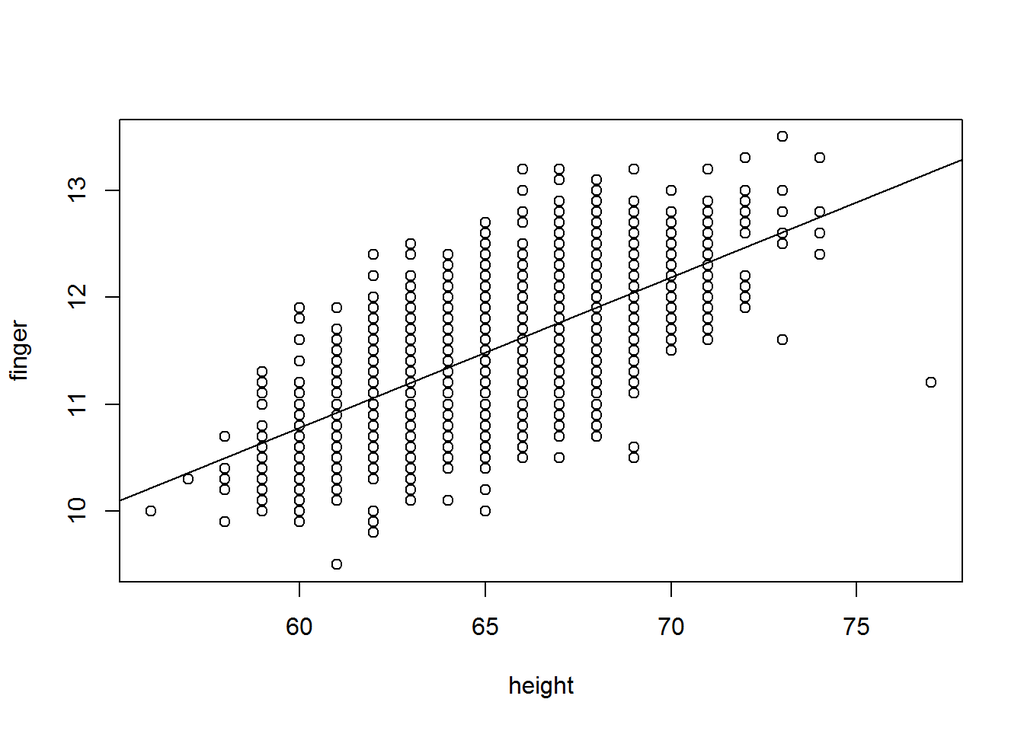

```r
plot(finger ~ height, data = crimtab.2.long.df)
abline(lm(finger ~ height, data = crimtab.2.long.df)$coefficient)
```

```r
crimtab.lm <- lm(finger ~ height, data = crimtab.2.long.df)
summary(crimtab.lm)
```

```
##
## Call:
## lm(formula = finger ~ height, data = crimtab.2.long.df)
##
## Residuals:
##      Min       1Q   Median       3Q      Max
## -1.96885 -0.28417  0.00051  0.27516  1.57850
##
## Coefficients:
##             Estimate Std. Error t value Pr(>|t|)
## (Intercept) 2.337388   0.193830   12.06   <2e-16 ***
## height      0.140668   0.002958   47.55   <2e-16 ***
## ---
## Signif. codes:  0 '***' 0.001 '**' 0.01 '*' 0.05 '.' 0.1 ' ' 1
##
## Residual standard error: 0.4144 on 2998 degrees of freedom
## Multiple R-squared:   0.43,  Adjusted R-squared:  0.4298
## F-statistic:  2261 on 1 and 2998 DF,  p-value: < 2.2e-16
```

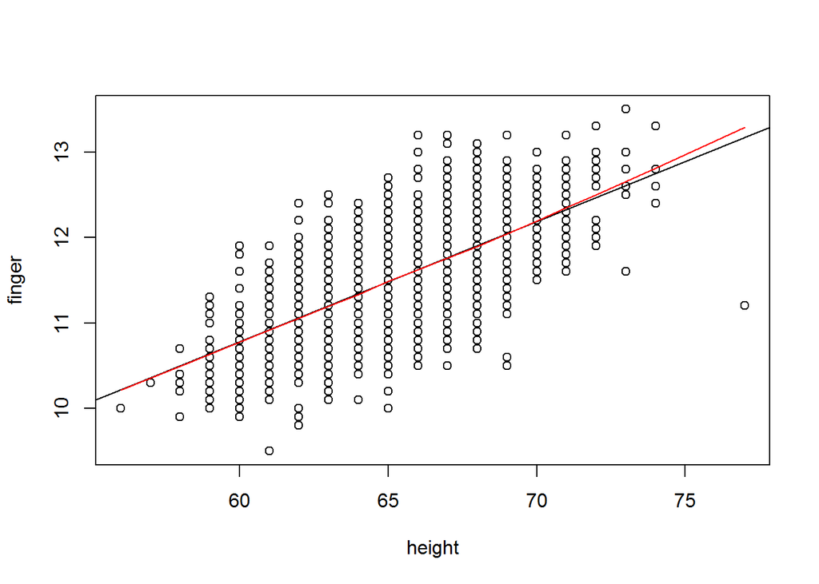

```r
plot(finger ~ height, data = crimtab.2.long.df)
abline(lm(finger ~ height, data = crimtab.2.long.df)$coefficient)
lines(lowess(crimtab.2.long.df$height, crimtab.2.long.df$finger),col = "red")
```

## 각 변수들 정규성을 검정

많은 통계적 추론에서는 자료의 독립성과 정규성(자료가 정규분포를 따른다 것을 의미함)을 가정한다. 따라서 자료의 정규성을 가정하는 통계학적인 분석 방법을 적용하고자 하는 경우에 자료가 정규분포를 따르는지 검정하고자 하는 의미에서 Q-Q 산점도를 이용한다.

*키와 관련된 정규성 검정

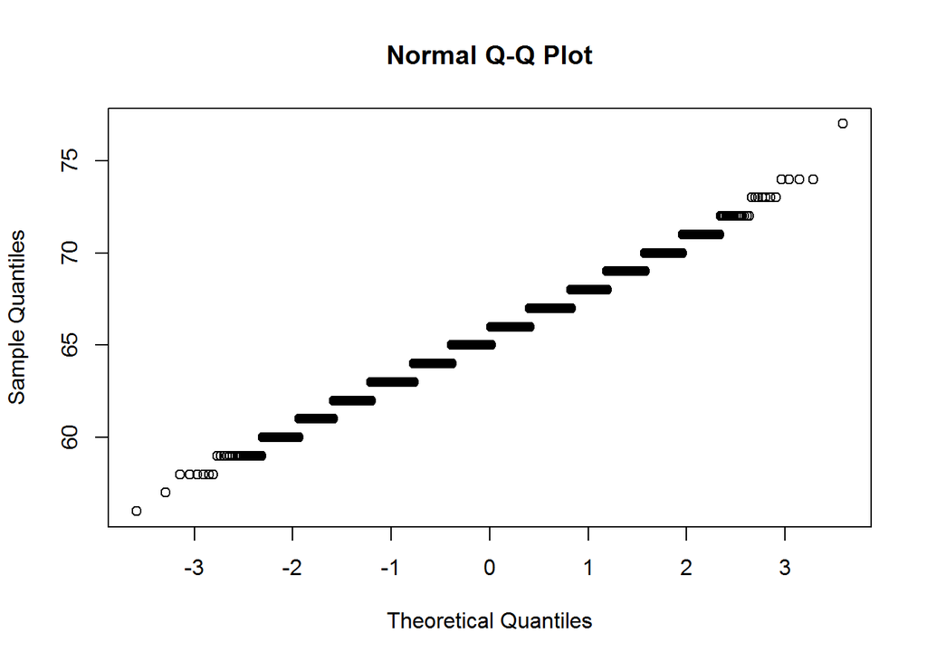

```r
qqnorm(crimtab.2.long.df$height)
```

*손가락과 관련된 정규성 검

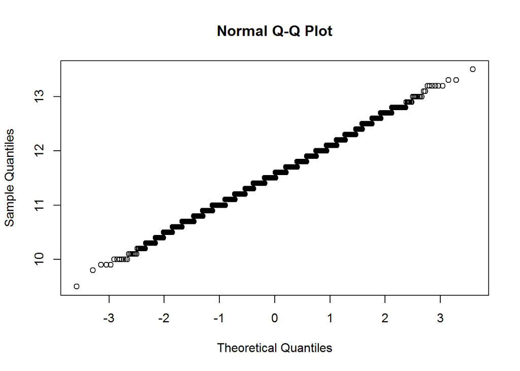

```r
qqnorm(crimtab.2.long.df$finger)
```

위의 그림을 통해, Q-Q 산점도에 나타나는 두 변수가 직선형태를 나타낸다. 즉, 자료가 정규분포에 가깝다는 것을 의미한다.

## 각 변수들 빈도표 작성.

*키와 관련된 빈도표.

```r
crimtab.2.long.df$height
```

```
##    [1] 56 57 58 58 58 58 58 58 59 59 59 59 59 59 59 59 59 59 59 59 59 59 59
##   [24] 59 59 59 59 59 59 59 59 60 60 60 60 60 60 60 60 60 60 60 60 60 60 60
##   [47] 60 60 60 60 60 60 60 60 60 60 60 60 60 60 60 60 60 60 60 60 60 60 60
##   [70] 60 60 60 60 60 60 60 60 60 60 61 61 61 61 61 61 61 61 61 61 61 61 61
##   [93] 61 61 61 61 61 61 61 61 61 61 61 61 61 61 61 61 61 61 61 61 61 61 61
##  [116] 61 61 61 61 61 61 61 61 61 61 61 61 61 61 61 61 61 61 61 61 61 61 61
##  [139] 61 61 61 61 61 61 61 61 61 61 61 61 61 61 61 61 61 61 61 61 61 61 61
##  [162] 61 61 61 61 61 61 61 61 62 62 62 62 62 62 62 62 62 62 62 62 62 62 62
##  [185] 62 62 62 62 62 62 62 62 62 62 62 62 62 62 62 62 62 62 62 62 62 62 62
##  [208] 62 62 62 62 62 62 62 62 62 62 62 62 62 62 62 62 62 62 62 62 62 62 62
##  [231] 62 62 62 62 62 62 62 62 62 62 62 62 62 62 62 62 62 62 62 62 62 62 62
##  [254] 62 62 62 62 62 62 62 62 62 62 62 62 62 62 62 62 62 62 62 62 62 62 62
##  [277] 62 62 62 62 62 62 62 62 62 62 62 62 62 62 62 62 62 62 62 62 62 62 62
##  [300] 62 62 62 62 62 62 62 62 62 62 62 62 62 62 62 62 62 62 62 62 62 62 62
##  [323] 62 62 62 62 62 62 62 62 62 62 62 62 62 62 62 62 62 62 62 62 62 62 63
```

[output cut: 116 more lines]

```r
table(crimtab.2.long.df$height)
```

```
##
##  56  57  58  59  60  61  62  63  64  65  66  67  68  69  70  71  72  73
##   1   1   6  23  48  90 175 317 393 462 458 413 264 177  97  46  17   7
##  74  77
##   4   1
```

```r
(height <- table(crimtab.2.long.df$height))
```

```
##
##  56  57  58  59  60  61  62  63  64  65  66  67  68  69  70  71  72  73
##   1   1   6  23  48  90 175 317 393 462 458 413 264 177  97  46  17   7
##  74  77
##   4   1
```

```r
str(height)
```

```
##  'table' int [1:20(1d)] 1 1 6 23 48 90 175 317 393 462 ...
##  - attr(*, "dimnames")=List of 1
##   ..$ : chr [1:20] "56" "57" "58" "59" ...
```

```r
data.frame(height)
```

```
##    Var1 Freq
## 1    56    1
## 2    57    1
## 3    58    6
## 4    59   23
## 5    60   48
## 6    61   90
## 7    62  175
## 8    63  317
## 9    64  393
## 10   65  462
## 11   66  458
## 12   67  413
## 13   68  264
## 14   69  177
## 15   70   97
## 16   71   46
## 17   72   17
## 18   73    7
## 19   74    4
## 20   77    1
```

```r
(height.table <- data.frame(height))
```

```
##    Var1 Freq
## 1    56    1
## 2    57    1
## 3    58    6
## 4    59   23
## 5    60   48
## 6    61   90
## 7    62  175
## 8    63  317
## 9    64  393
## 10   65  462
## 11   66  458
## 12   67  413
## 13   68  264
## 14   69  177
## 15   70   97
## 16   71   46
## 17   72   17
## 18   73    7
## 19   74    4
## 20   77    1
```

```r
str(height.table)
```

```
## 'data.frame':    20 obs. of  2 variables:
##  $ Var1: Factor w/ 20 levels "56","57","58",..: 1 2 3 4 5 6 7 8 9 10 ...
##  $ Freq: int  1 1 6 23 48 90 175 317 393 462 ...
```

```r
dimnames(height.table)<-list(c("1","2","3","4","5","6","7","8","9","10","11",
"12","13","14","15","16","17","18","19","20"),c("키","빈도수"))
pander(height.table)
```

| 키 | 빈도수 |
| --- | --- |
| 56 | 1 |
| 57 | 1 |
| 58 | 6 |
| 59 | 23 |
| 60 | 48 |
| 61 | 90 |
| 62 | 175 |
| 63 | 317 |
| 64 | 393 |
| 65 | 462 |
| 66 | 458 |
| 67 | 413 |
| 68 | 264 |
| 69 | 177 |
| 70 | 97 |
| 71 | 46 |
| 72 | 17 |
| 73 | 7 |
| 74 | 4 |
| 77 | 1 |

*손가락와 관련된 빈도표.

```r
crimtab.2.long.df$finger
```

```
##    [1] 10.0 10.3  9.9 10.2 10.2 10.3 10.4 10.7 10.0 10.1 10.2 10.2 10.3
##   [14] 10.3 10.3 10.4 10.5 10.6 10.7 10.7 10.8 10.8 11.0 11.0 11.1 11.1
##   [27] 11.1 11.2 11.2 11.2 11.3  9.9 10.0 10.0 10.1 10.1 10.1 10.2 10.2
##   [40] 10.3 10.3 10.4 10.4 10.5 10.5 10.5 10.6 10.6 10.6 10.6 10.7 10.7
##   [53] 10.7 10.7 10.8 10.8 10.8 10.8 10.8 10.9 10.9 11.0 11.0 11.0 11.0
##   [66] 11.0 11.0 11.1 11.1 11.1 11.2 11.2 11.4 11.4 11.4 11.6 11.6 11.8
##   [79] 11.9  9.5 10.1 10.2 10.3 10.3 10.4 10.4 10.4 10.5 10.5 10.5 10.5
##   [92] 10.5 10.5 10.5 10.6 10.6 10.6 10.6 10.6 10.7 10.7 10.7 10.7 10.7
##  [105] 10.7 10.7 10.7 10.7 10.8 10.8 10.8 10.8 10.8 10.8 10.9 10.9 10.9
##  [118] 10.9 10.9 10.9 11.0 11.0 11.0 11.0 11.0 11.0 11.0 11.0 11.0 11.0
##  [131] 11.0 11.0 11.1 11.1 11.1 11.1 11.1 11.1 11.1 11.1 11.1 11.1 11.1
##  [144] 11.1 11.2 11.2 11.2 11.2 11.2 11.2 11.2 11.3 11.3 11.3 11.3 11.3
##  [157] 11.4 11.4 11.4 11.4 11.5 11.5 11.5 11.5 11.5 11.6 11.7 11.7 11.9
##  [170]  9.8  9.9 10.0 10.0 10.3 10.3 10.3 10.4 10.4 10.4 10.5 10.5 10.5
##  [183] 10.5 10.5 10.5 10.6 10.6 10.6 10.6 10.6 10.6 10.6 10.6 10.6 10.7
```

[output cut: 216 more lines]

```r
table(crimtab.2.long.df$finger)
```

```
##
##  9.5  9.8  9.9   10 10.1 10.2 10.3 10.4 10.5 10.6 10.7 10.8 10.9   11 11.1
##    1    1    3    7    7   10   17   20   30   44   74   75  102  163  152
## 11.2 11.3 11.4 11.5 11.6 11.7 11.8 11.9   12 12.1 12.2 12.3 12.4 12.5 12.6
##  183  164  228  233  226  232  184  162  163  126   91   89   44   52   35
## 12.7 12.8 12.9   13 13.1 13.2 13.3 13.5
##   31   25    7    8    2    6    2    1
```

```r
(finger <- table(crimtab.2.long.df$finger))
```

```
##
##  9.5  9.8  9.9   10 10.1 10.2 10.3 10.4 10.5 10.6 10.7 10.8 10.9   11 11.1
##    1    1    3    7    7   10   17   20   30   44   74   75  102  163  152
## 11.2 11.3 11.4 11.5 11.6 11.7 11.8 11.9   12 12.1 12.2 12.3 12.4 12.5 12.6
##  183  164  228  233  226  232  184  162  163  126   91   89   44   52   35
## 12.7 12.8 12.9   13 13.1 13.2 13.3 13.5
##   31   25    7    8    2    6    2    1
```

```r
str(finger)
```

```
##  'table' int [1:38(1d)] 1 1 3 7 7 10 17 20 30 44 ...
##  - attr(*, "dimnames")=List of 1
##   ..$ : chr [1:38] "9.5" "9.8" "9.9" "10" ...
```

```r
data.frame(finger)
```

```
##    Var1 Freq
## 1   9.5    1
## 2   9.8    1
## 3   9.9    3
## 4    10    7
## 5  10.1    7
## 6  10.2   10
## 7  10.3   17
## 8  10.4   20
## 9  10.5   30
## 10 10.6   44
## 11 10.7   74
## 12 10.8   75
## 13 10.9  102
## 14   11  163
```

[output cut: 24 more lines]

```r
(finger.table <- data.frame(finger))
```

```
##    Var1 Freq
## 1   9.5    1
## 2   9.8    1
## 3   9.9    3
## 4    10    7
## 5  10.1    7
## 6  10.2   10
## 7  10.3   17
## 8  10.4   20
## 9  10.5   30
## 10 10.6   44
## 11 10.7   74
## 12 10.8   75
## 13 10.9  102
## 14   11  163
```

[output cut: 24 more lines]

```r
str(finger.table)
```

```
## 'data.frame':    38 obs. of  2 variables:
##  $ Var1: Factor w/ 38 levels "9.5","9.8","9.9",..: 1 2 3 4 5 6 7 8 9 10 ...
##  $ Freq: int  1 1 3 7 7 10 17 20 30 44 ...
```

```r
dimnames(finger.table)<-list(c("1","2","3","4","5","6","7","8","9","10","11","12","13","14","15","16","17","18","19","20","21","22","23","24","25","26","27","28","29","30","31","32","33","34","35","36","37","38"),c("손가락","빈도수"))
pander(finger.table)
```

| 손가락 | 빈도수 |
| --- | --- |
| 9.5 | 1 |
| 9.8 | 1 |
| 9.9 | 3 |
| 10 | 7 |
| 10.1 | 7 |
| 10.2 | 10 |
| 10.3 | 17 |
| 10.4 | 20 |
| 10.5 | 30 |
| 10.6 | 44 |
| 10.7 | 74 |
| 10.8 | 75 |
| 10.9 | 102 |
| 11 | 163 |
| 11.1 | 152 |
| 11.2 | 183 |
| 11.3 | 164 |
| 11.4 | 228 |
| 11.5 | 233 |
| 11.6 | 226 |
| 11.7 | 232 |
| 11.8 | 184 |
| 11.9 | 162 |
| 12 | 163 |
| 12.1 | 126 |
| 12.2 | 91 |
| 12.3 | 89 |
| 12.4 | 44 |
| 12.5 | 52 |
| 12.6 | 35 |
| 12.7 | 31 |
| 12.8 | 25 |
| 12.9 | 7 |
| 13 | 8 |
| 13.1 | 2 |
| 13.2 | 6 |
| 13.3 | 2 |
| 13.5 | 1 |

## 각 변수들을 히스토그램으로 그리기.

*키의 히스토그램

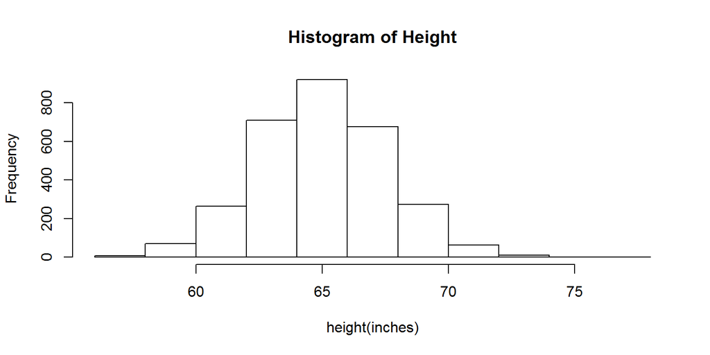

```r
hist(crimtab.2.long.df$height, main="Histogram of Height", xlab="height(inches)")
```

*손가락의 히스토그램

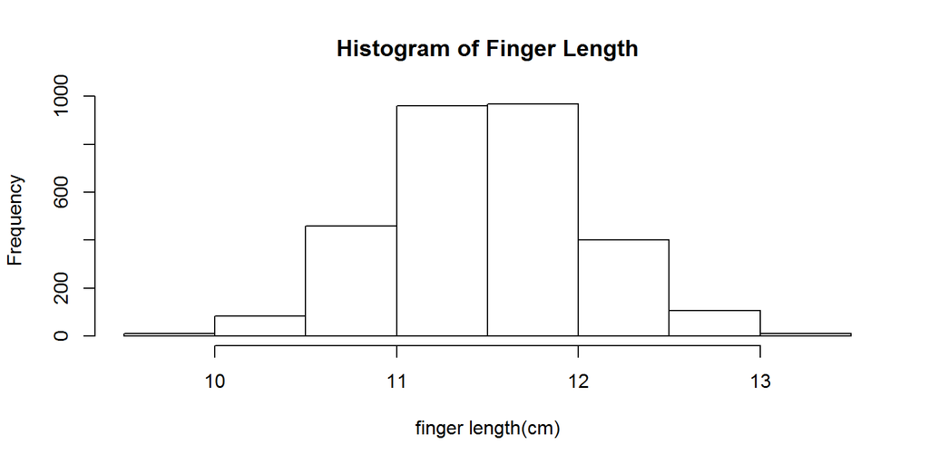

```r
hist(crimtab.2.long.df$finger, main="Histogram of Finger Length", xlab= "finger length(cm)")
```

## 키의 정규곡선 그리기.

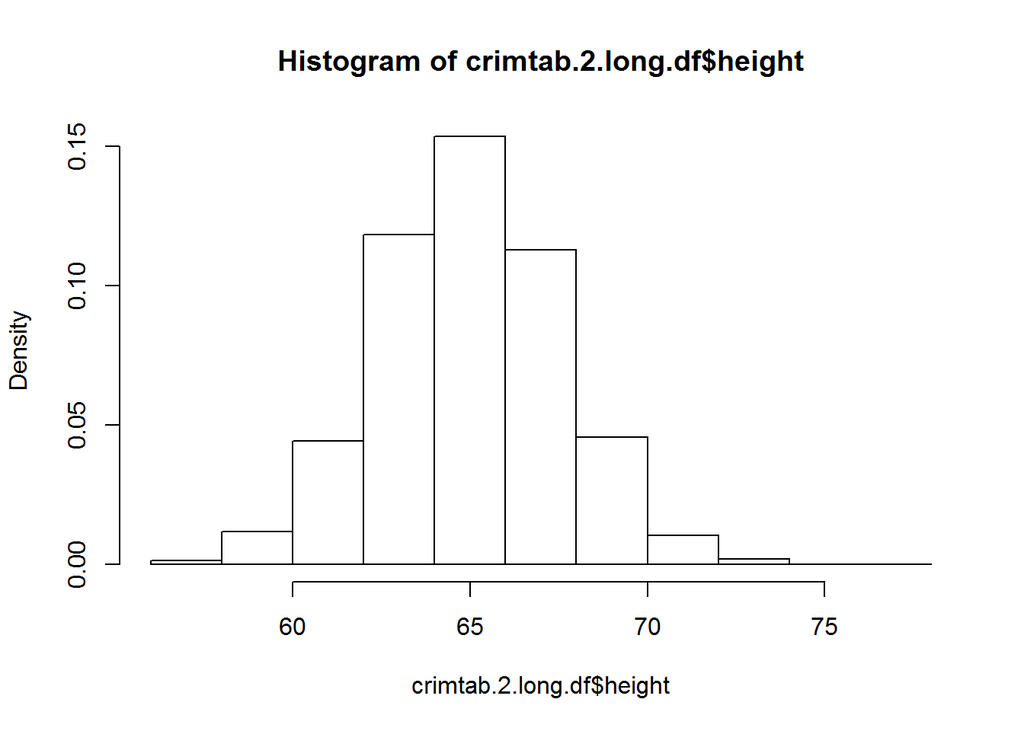

```r
hist(crimtab.2.long.df$height, probability = TRUE)
```

```r
(crimtab.height <- hist(crimtab.2.long.df$height, plot = FALSE))
```

```
## $breaks
##  [1] 56 58 60 62 64 66 68 70 72 74 76 78
##
## $counts
##  [1]   8  71 265 710 920 677 274  63  11   0   1
##
## $density
##  [1] 0.0013333333 0.0118333333 0.0441666667 0.1183333333 0.1533333333
##  [6] 0.1128333333 0.0456666667 0.0105000000 0.0018333333 0.0000000000
## [11] 0.0001666667
##
## $mids
##  [1] 57 59 61 63 65 67 69 71 73 75 77
##
## $xname
## [1] "crimtab.2.long.df$height"
##
## $equidist
## [1] TRUE
##
## attr(,"class")
## [1] "histogram"
```

```r
list(breaks = crimtab.height$breaks, counts = crimtab.height$counts, density = crimtab.height$density, mids = crimtab.height$mids)
```

```
## $breaks
##  [1] 56 58 60 62 64 66 68 70 72 74 76 78
##
## $counts
##  [1]   8  71 265 710 920 677 274  63  11   0   1
##
## $density
##  [1] 0.0013333333 0.0118333333 0.0441666667 0.1183333333 0.1533333333
##  [6] 0.1128333333 0.0456666667 0.0105000000 0.0018333333 0.0000000000
## [11] 0.0001666667
##
## $mids
##  [1] 57 59 61 63 65 67 69 71 73 75 77
```

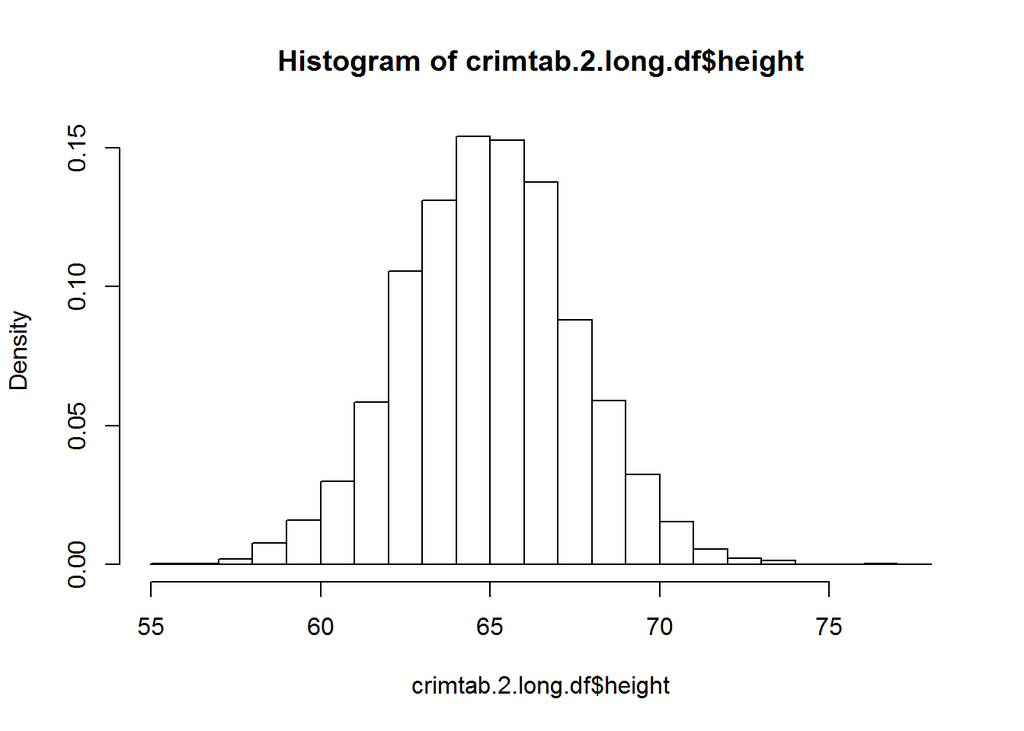

```r
crimtab.2.hist <- hist(crimtab.2.long.df$height, probability = TRUE, breaks = 55:78)
```

•히스토그램을 보기 쉽게 하기 위해서 메인 타이틀과 서브 타이틀, x축 라벨, y축 라벨 설정 및 평균을 중심으로 ± 표준편차 만큼 떨어진 자료를 붉은 색 수직점선으로 표시.

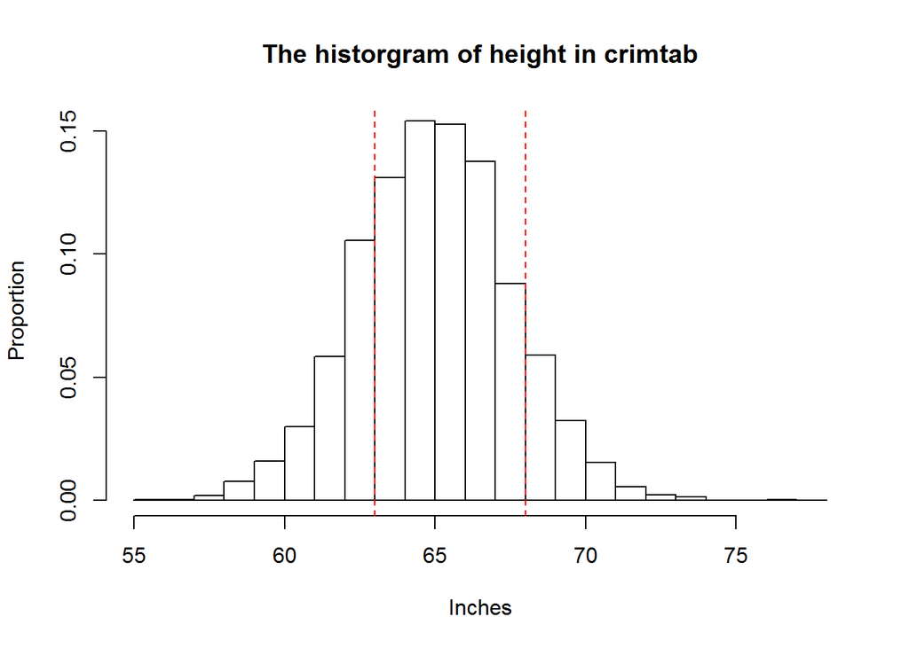

```r
main.title <- "The historgram of height in crimtab"
x.lab <- "Inches"
y.lab <- "Proportion"
hist(crimtab.2.long.df$height, breaks = 55:78, probability = TRUE, main = main.title, xlab = x.lab, ylab = y.lab)
abline(v = c(63, 68), lty = 2, col = "red")
```

•5개의 직사각형으로 파악하고 향후 면적 계산을 쉽게 하기 위하여 다음과 같이 좌표 설정

```r
y <- crimtab.2.hist$density[9:13]
x.coord<-c(63, 68, 68, rep(67:64, each = 2), 63)
y.coord<-c(rep(0, 2), rep(rev(y), each = 2))
list(x.coord, y.coord)
```

```
## [[1]]
##  [1] 63 68 68 67 67 66 66 65 65 64 64 63
##
## [[2]]
##  [1] 0.0000000 0.0000000 0.0880000 0.0880000 0.1376667 0.1376667 0.1526667
##  [8] 0.1526667 0.1540000 0.1540000 0.1310000 0.1310000
```

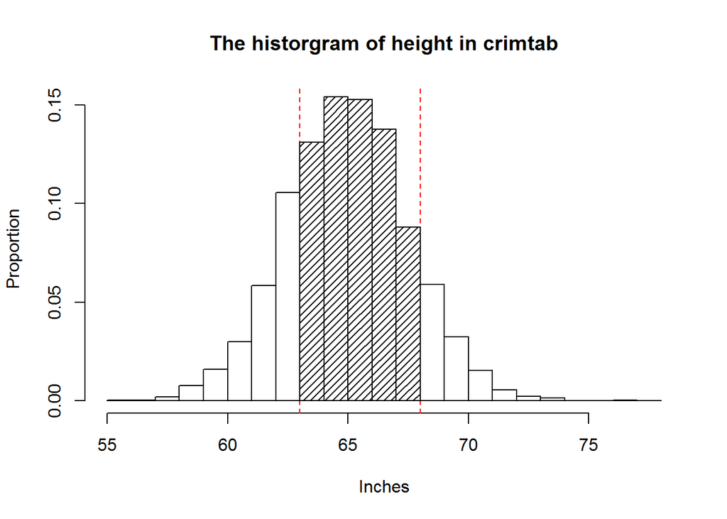

```r
hist(crimtab.2.long.df$height, breaks = 55:78, probability = TRUE, main = main.title, xlab = x.lab, ylab = y.lab)
abline(v = c(63, 68), lty = 2, col = "red")
polygon(x.coord, y.coord, density = 20)
```

키의 평균과 표준편차 구하기

```r
summary(crimtab.2.long.df$height)
```

```
##    Min. 1st Qu.  Median    Mean 3rd Qu.    Max.
##   56.00   64.00   65.00   65.47   67.00   77.00
```

```r
sd(crimtab.2.long.df$height)
```

```
## [1] 2.557757
```

```r
(x <- c(63, 64:67, 68))
```

```
## [1] 63 64 65 66 67 68
```

```r
y
```

```
## [1] 0.1310000 0.1540000 0.1526667 0.1376667 0.0880000
```

```r
diff(x)
```

```
## [1] 1 1 1 1 1
```

```r
diff(x) * y
```

```
## [1] 0.1310000 0.1540000 0.1526667 0.1376667 0.0880000
```

```r
sum(diff(x) * y)
```

```
## [1] 0.6633333
```

Comparison with normal curve •이론적인 정규분포 밀도함수 곡선을 히스토그램에 덧붙여 그림.

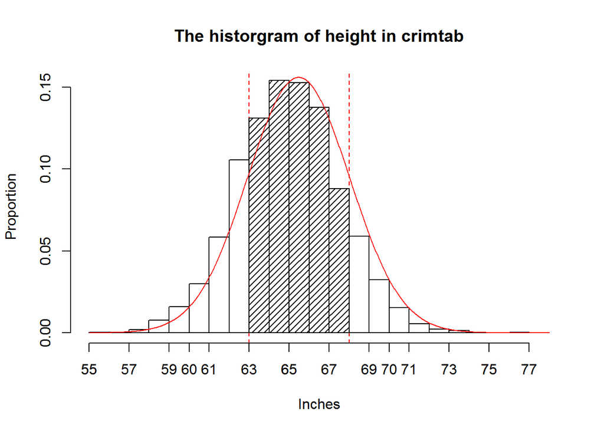

```r
mean.height <- mean(crimtab.2.long.df$height)
sd.height <- sd(crimtab.2.long.df$height)
x.height <- seq(55, 78, length = 1000)
y.norm <- dnorm(x.height, mean = mean.height, sd = sd.height)
hist(crimtab.2.long.df$height, breaks = 55:78, probability = TRUE, main = main.title, xlab = x.lab, ylab = y.lab)
abline(v = c(63, 68), lty = 2, col = "red")
polygon(x.coord, y.coord, density = 20)
lines(x.height, y.norm, col = "red")
axis(side = 1, at = seq(55, 78, by = 2), labels = seq(55, 78, by = 2))
axis(side = 2)
```

ggplot

Basic histogram

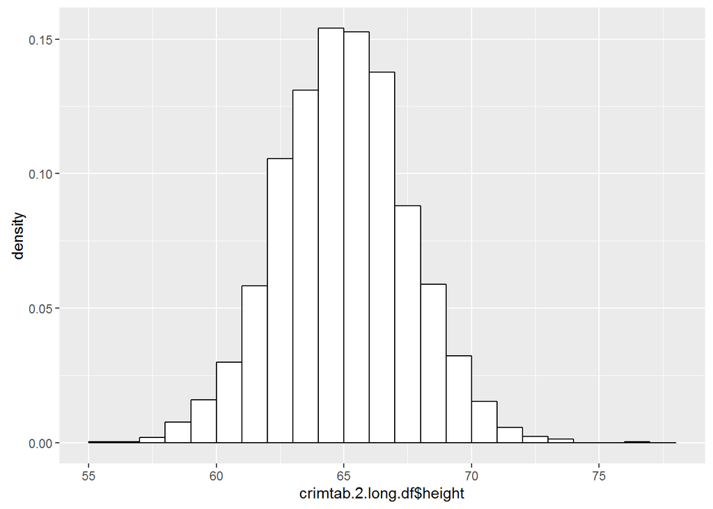

```r
(g1 <- ggplot(data.frame(crimtab.2.long.df$height), aes(x = crimtab.2.long.df$height)) + geom_histogram(aes(y = ..density..), binwidth = 1, breaks = 55:78, fill = "white", colour = "black"))
```

Mean ±±SD

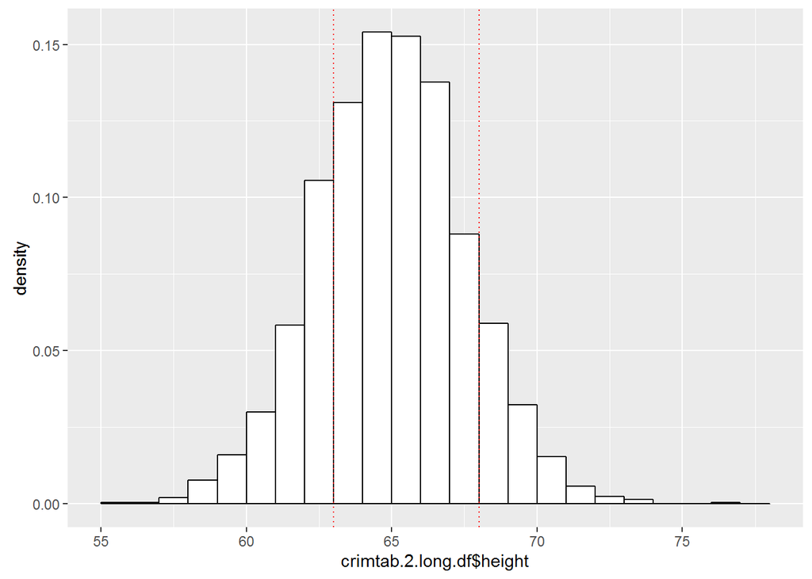

```r
 (g2 <- g1 + geom_vline(xintercept = c(63, 68), linetype = "dotted", colour = "red"))
```

x-axis label and main title

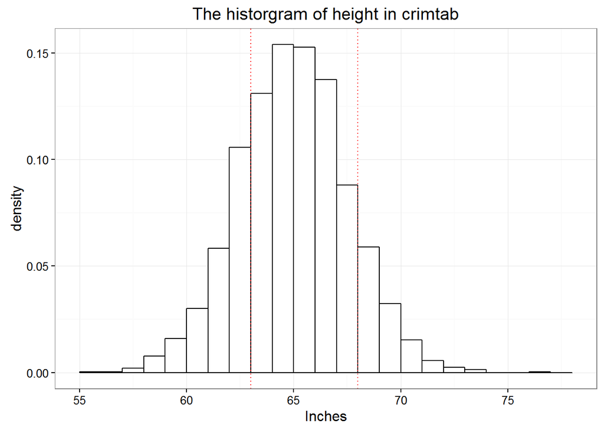

```r
(g3 <- g2 + theme_bw() + xlab("Inches") + ggtitle("The historgram of height in crimtab"))
```

Shading the area

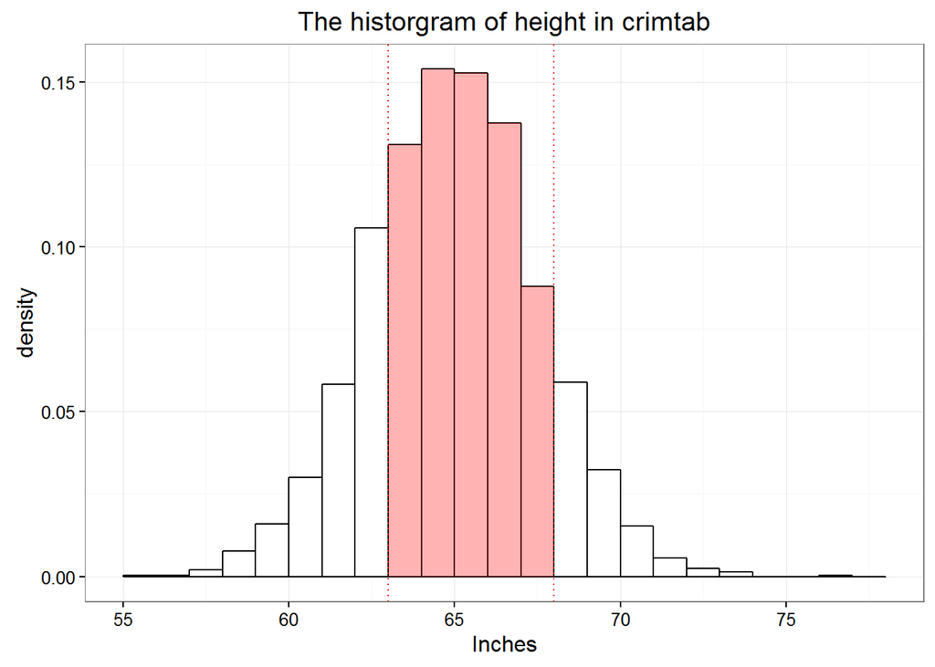

```r
(g4 <- g3 + geom_polygon(aes(x = x.coord, y = y.coord), data = data.frame(x.coord, y.coord), alpha = 0.3, fill = "red"))
```

Normal curve added

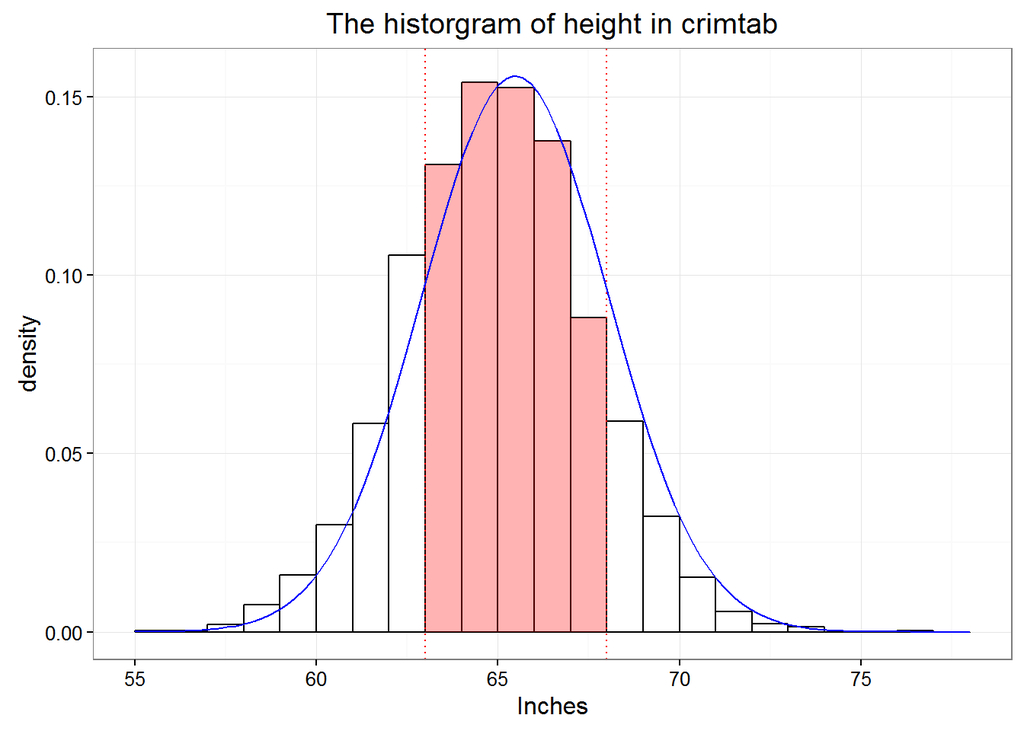

```r
x.curve <- seq(55, 78, length = 100)
y.curve <- dnorm(x.curve, mean = mean.height, sd = sd.height)
(g5 <- g4 + geom_line(aes(x = x.curve, y = y.curve), data = data.frame(x.curve, y.curve), colour = "blue"))
```

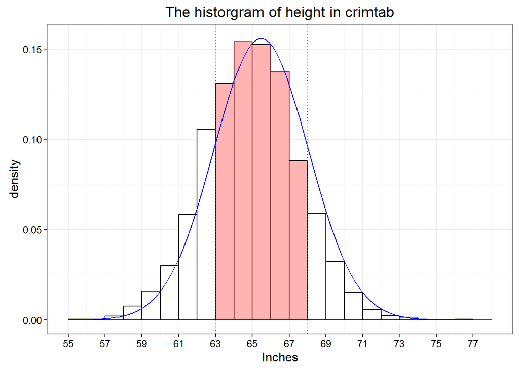

```r
(g6 <- g5 + scale_x_continuous(breaks = seq(55, 78, by = 2), labels = seq(55, 78, by = 2)))
```

## 손가락 정규곡선 그리기.

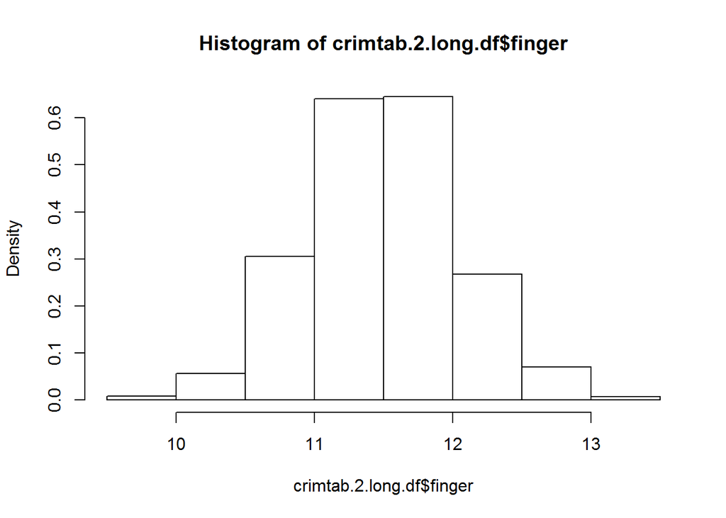

```r
hist(crimtab.2.long.df$finger, probability = TRUE)
```

```r
(crimtab.finger <- hist(crimtab.2.long.df$finger, plot = FALSE))
```

```
## $breaks
## [1]  9.5 10.0 10.5 11.0 11.5 12.0 12.5 13.0 13.5
##
## $counts
## [1]  12  84 458 960 967 402 106  11
##
## $density
## [1] 0.008000000 0.056000000 0.305333333 0.640000000 0.644666667 0.268000000
## [7] 0.070666667 0.007333333
##
## $mids
## [1]  9.75 10.25 10.75 11.25 11.75 12.25 12.75 13.25
##
## $xname
## [1] "crimtab.2.long.df$finger"
##
## $equidist
## [1] TRUE
##
## attr(,"class")
## [1] "histogram"
```

```r
list(breaks = crimtab.finger$breaks, counts = crimtab.finger$counts, density = crimtab.finger$density, mids = crimtab.finger$mids)
```

```
## $breaks
## [1]  9.5 10.0 10.5 11.0 11.5 12.0 12.5 13.0 13.5
##
## $counts
## [1]  12  84 458 960 967 402 106  11
##
## $density
## [1] 0.008000000 0.056000000 0.305333333 0.640000000 0.644666667 0.268000000
## [7] 0.070666667 0.007333333
##
## $mids
## [1]  9.75 10.25 10.75 11.25 11.75 12.25 12.75 13.25
```

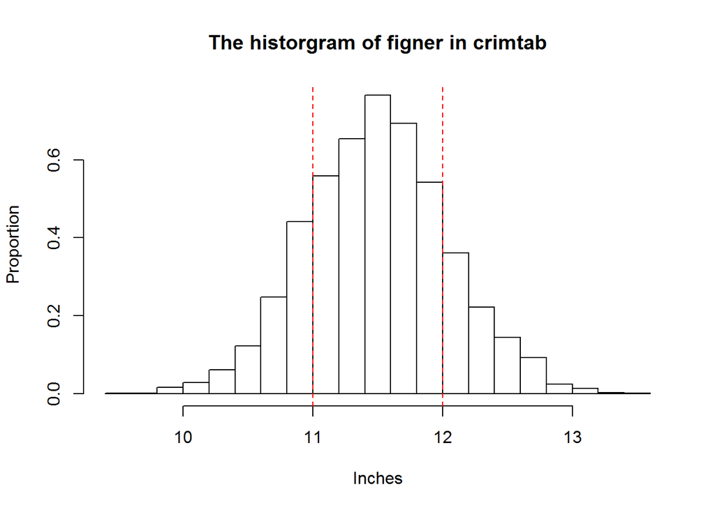

```r
main.title <- "The historgram of figner in crimtab"
x.lab <- "Inches"
y.lab <- "Proportion"
hist(crimtab.2.long.df$finger, nclass=19, probability = TRUE, main = main.title, xlab = x.lab, ylab = y.lab)
abline(v = c(11, 12), lty = 2, col = "red")
```

그 사이의 빗금영역을 표시하기 위하여 다각형의 좌표계산

```r
crimtab.finger$density[4:6]
```

```
## [1] 0.6400000 0.6446667 0.2680000
```

```r
y <- crimtab.finger$density[4:6]
```

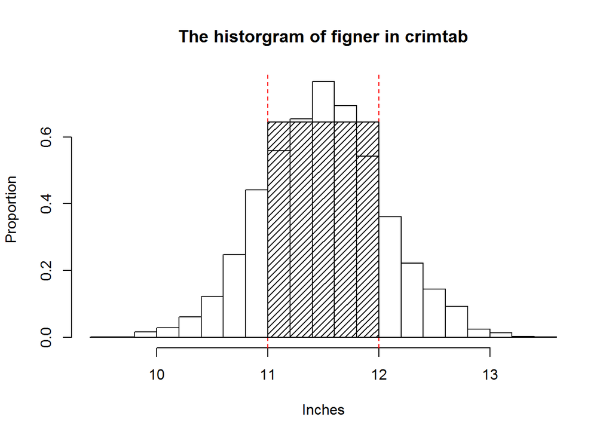

```r
x.coord<-c(11, 12, 12, rep(12:11, each = 2), 11)
y.coord<-c(rep(0, 2), rep(rev(y), each = 2))
hist(crimtab.2.long.df$finger, nclass=19, probability = TRUE, main = main.title, xlab = x.lab, ylab = y.lab)
abline(v = c(11, 12), lty = 2, col = "red")
polygon(x.coord, y.coord, density = 20)
```

```r
summary(crimtab.2.long.df$finger)
```

```
##    Min. 1st Qu.  Median    Mean 3rd Qu.    Max.
##    9.50   11.20   11.50   11.55   11.90   13.50
```

```r
sd(crimtab.2.long.df$finger)
```

```
## [1] 0.5487137
```

```r
(x <- c(11, 11:12, 12))
```

```
## [1] 11 11 12 12
```

```r
y
```

```
## [1] 0.6400000 0.6446667 0.2680000
```

```r
diff(x)
```

```
## [1] 0 1 0
```

```r
diff(x) * y
```

```
## [1] 0.0000000 0.6446667 0.0000000
```

```r
sum(diff(x) * y)
```

```
## [1] 0.6446667
```

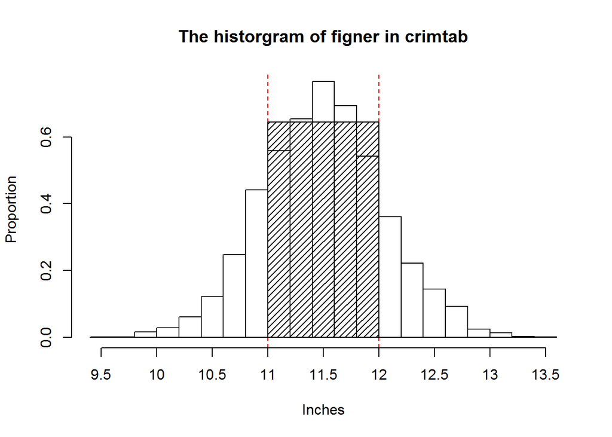

```r
mean.finger <- mean(crimtab.2.long.df$finger)
sd.finger <- sd(crimtab.2.long.df$figner)
x.finger <- seq(9.5, 13.5, length = 1000)
y.norm <- dnorm(x.finger, mean = mean.finger, sd = sd.finger)
hist(crimtab.2.long.df$finger, nclass=19, probability = TRUE, main = main.title, xlab = x.lab, ylab = y.lab)
abline(v = c(11, 12), lty = 2, col = "red")
polygon(x.coord, y.coord, density = 20)
lines(x.height, y.norm, col = "red")
axis(side = 1, at = seq(9.5, 13.5, by = 1), labels = seq(9.5, 13.5, by = 1))
axis(side = 2)
```

Basic histogram

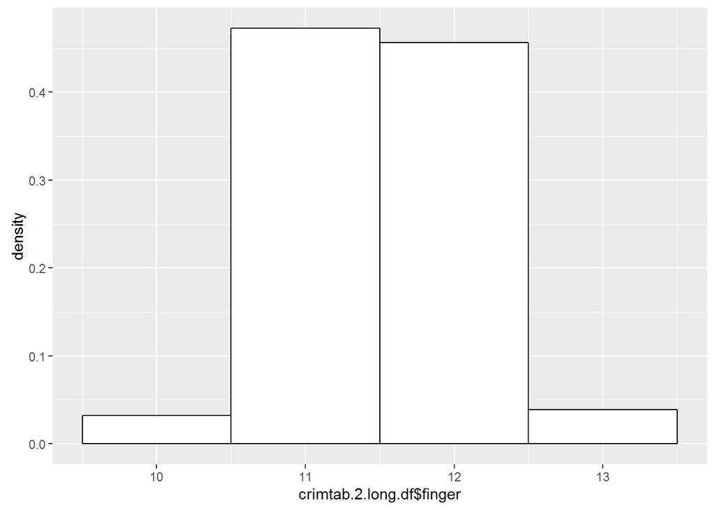

```r
(g1 <- ggplot(data.frame(crimtab.2.long.df$finger), aes(x = crimtab.2.long.df$finger)) + geom_histogram(aes(y = ..density..), binwidth = 1, breaks = 9.5:13.5, fill = "white", colour = "black"))
```

Mean ±±SD

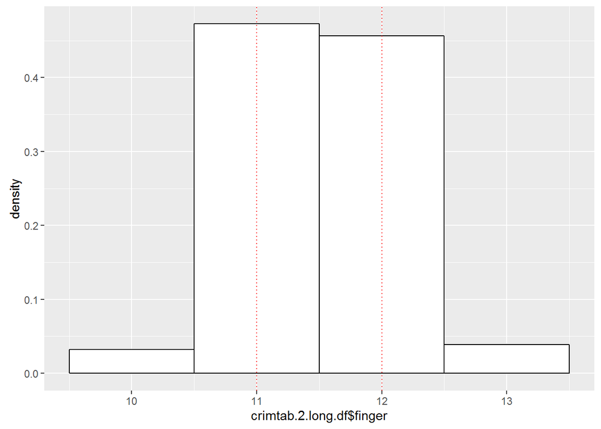

```r
 (g2 <- g1 + geom_vline(xintercept = c(11, 12), linetype = "dotted", colour = "red"))
```

x-axis label and main title

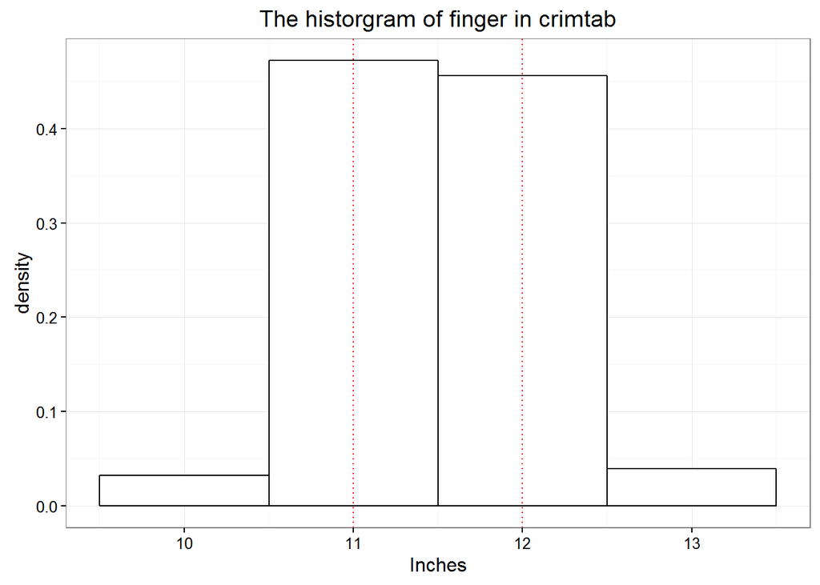

```r
(g3 <- g2 + theme_bw() + xlab("Inches") + ggtitle("The historgram of finger in crimtab"))
```

Shading the area

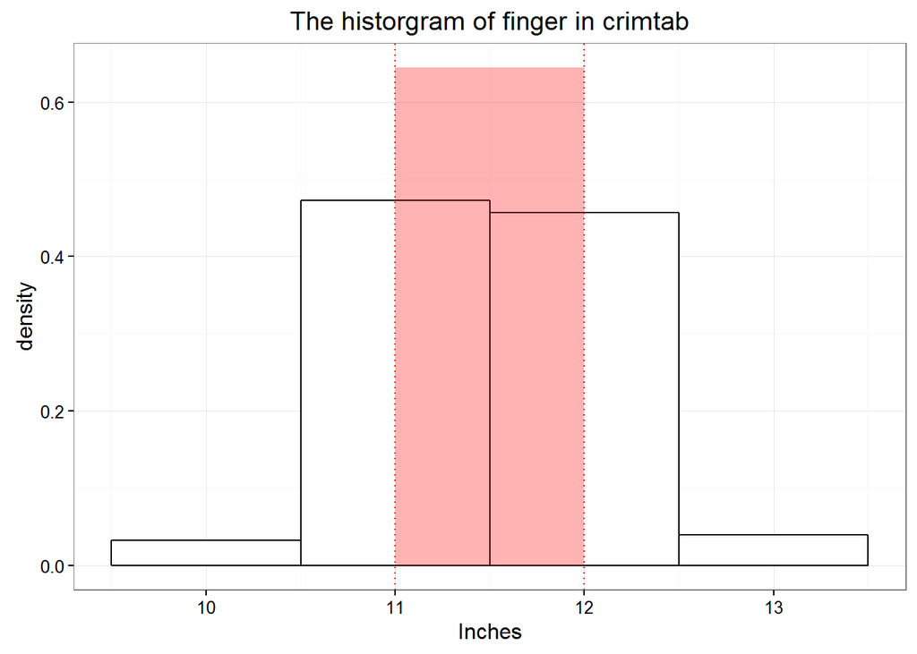

```r
(g4 <- g3 + geom_polygon(aes(x = x.coord, y = y.coord), data = data.frame(x.coord, y.coord), alpha = 0.3, fill = "red"))
```

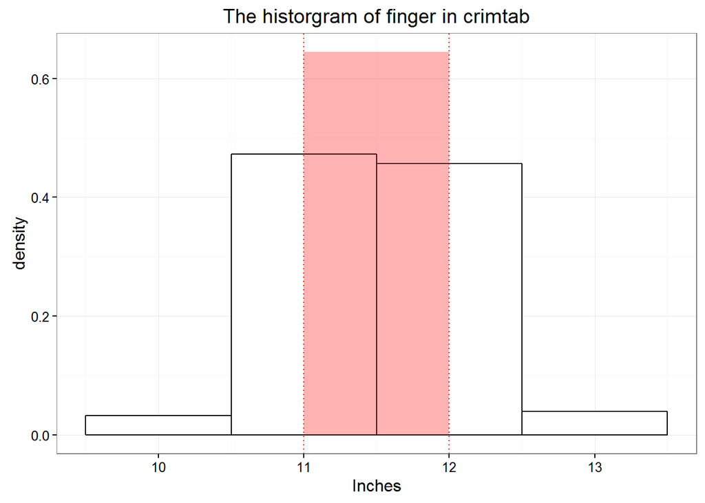

```r
x.curve <- seq(9.5, 13.5, length = 100)
y.curve <- dnorm(x.curve, mean = mean.finger, sd = sd.finger)
(g5 <- g4 + geom_line(aes(x = x.curve, y = y.curve), data = data.frame(x.curve, y.curve), colour = "blue"))
```

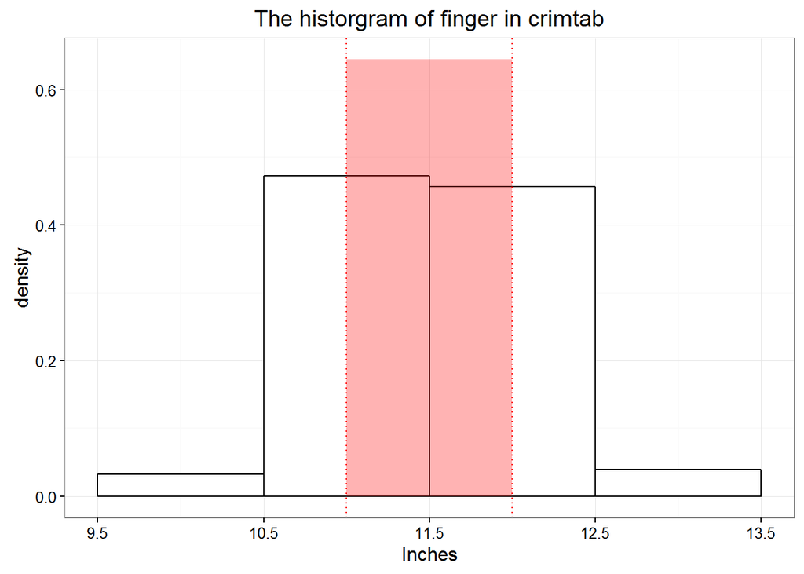

```r
(g6 <- g5 + scale_x_continuous(breaks = seq(9.5, 13.5, by = 1), labels = seq(9.5, 13.5, by = 1)))
```

### ggplot

- •키와 손가락 길이의 산점도

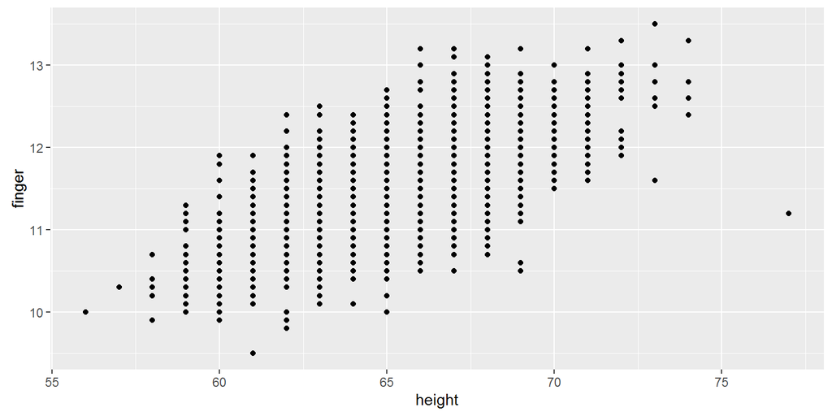

```r
library(ggplot2)
ggplot(crimtab.2.long.df, aes(x = height, y = finger)) + geom_point()
```

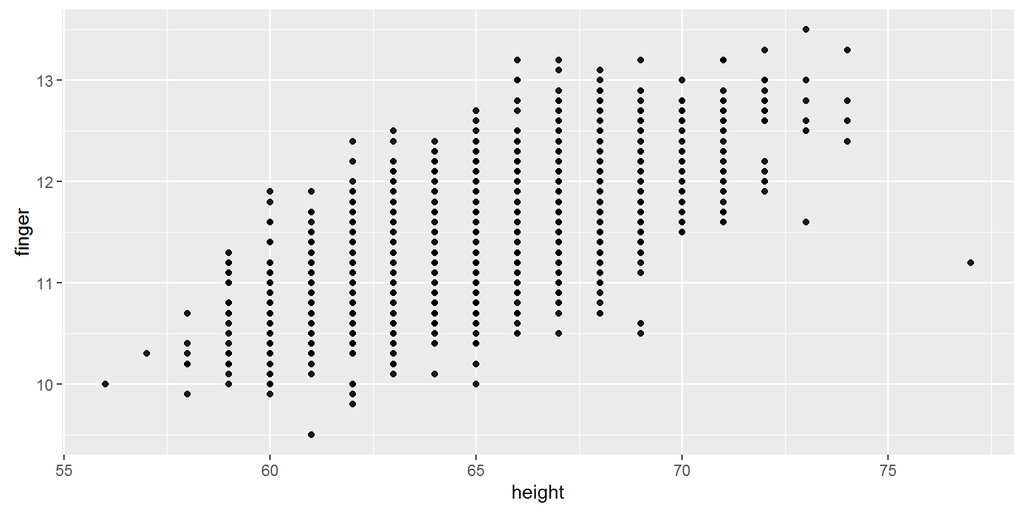

```r
ggplot(crimtab.2.long.df, aes(x = height, y = finger)) + geom_point(alpha = 0.9)
```

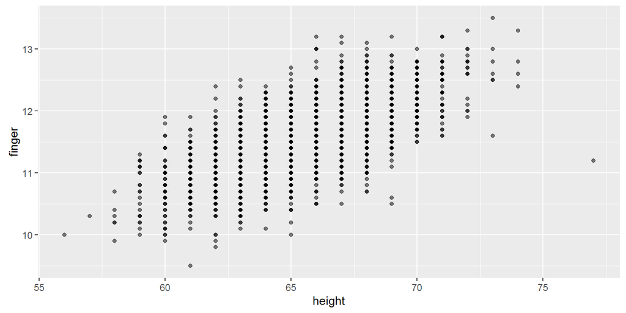

```r
ggplot(crimtab.2.long.df, aes(x = height, y = finger)) + geom_point(alpha = 0.5)
```

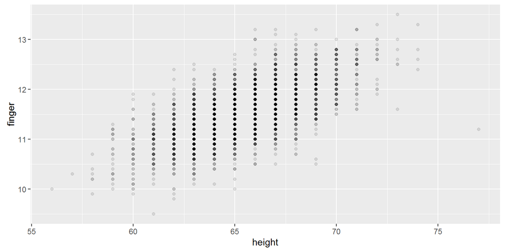

```r
ggplot(crimtab.2.long.df, aes(x = height, y = finger)) + geom_point(alpha = 0.1)
```

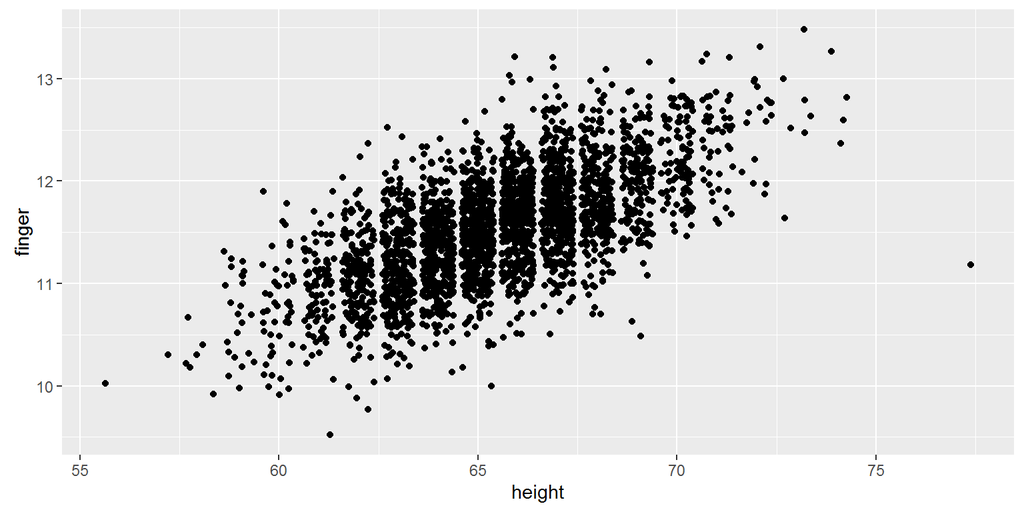

```r
ggplot(crimtab.2.long.df, aes(x = height, y = finger)) + geom_point(position = "jitter")
```

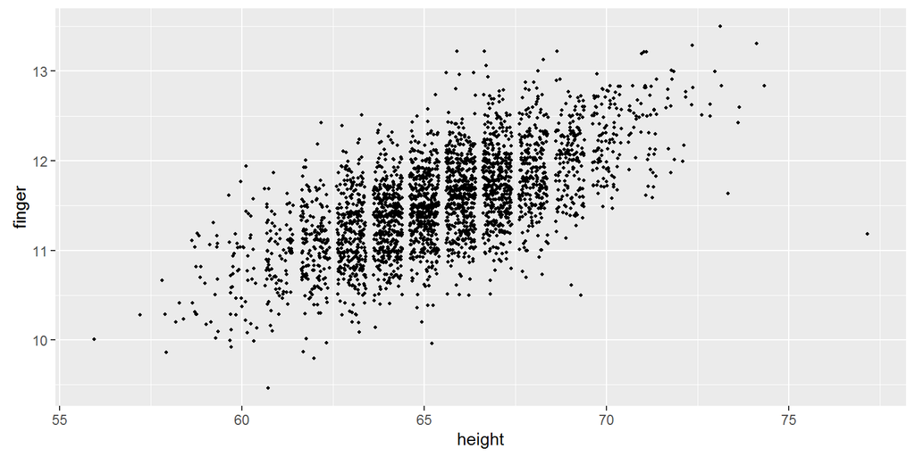

```r
ggplot(crimtab.2.long.df, aes(x = height, y = finger)) + geom_point(position = "jitter", size = 0.7)
```

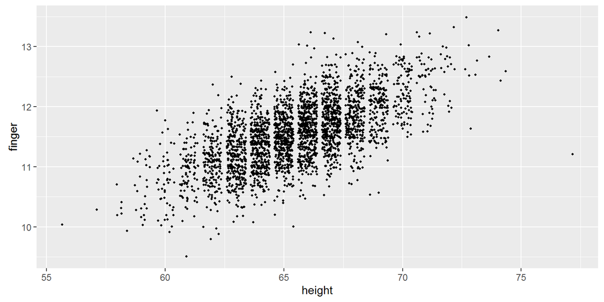

```r
ggplot(crimtab.2.long.df, aes(x = height, y = finger)) + geom_point(position = position_jitter(), size = 0.7)
```

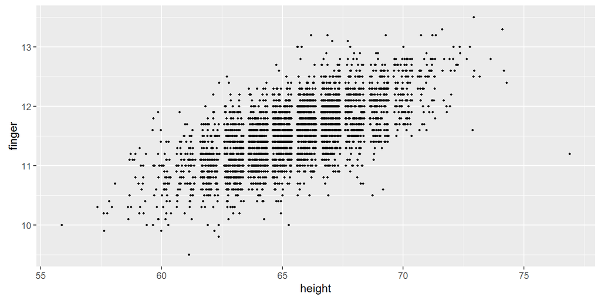

```r
ggplot(crimtab.2.long.df, aes(x = height, y = finger)) + geom_point(position = position_jitter(width = 1, height = 0), size = 0.7)
```

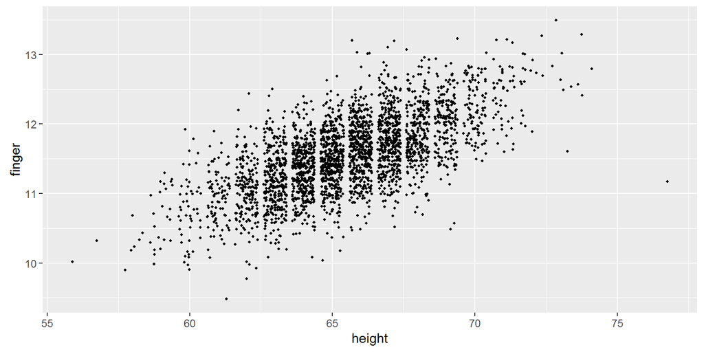

```r
ggplot(crimtab.2.long.df, aes(x = height, y = finger)) + geom_point(position = position_jitter(width = 1, height = 0.1), size = 0.7)
```

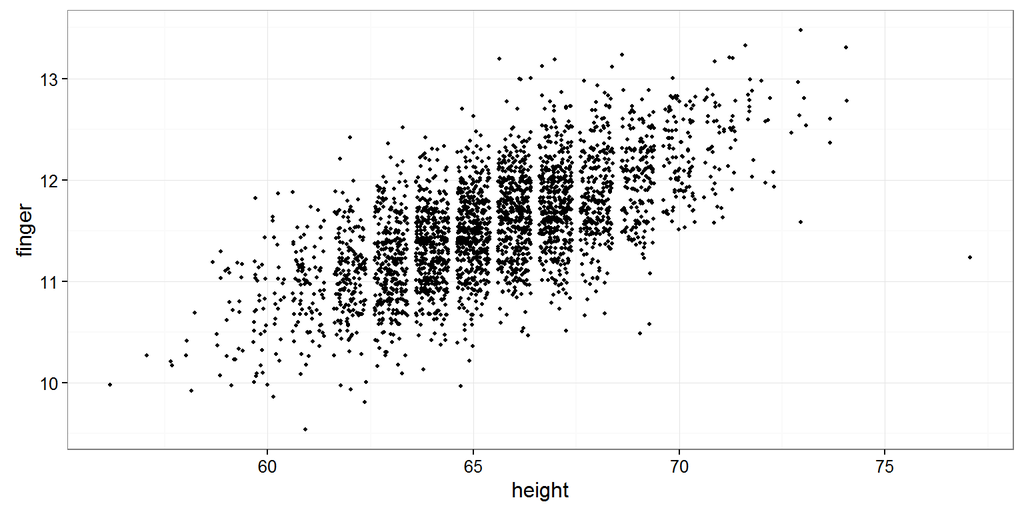

```r
ggplot(crimtab.2.long.df, aes(x = height, y = finger)) + geom_point(position = position_jitter(width = 1, height = 0.1), size = 0.7) +
  theme_bw()
```

### Data 마무리

```r
# save.image(file="../R/crimtab_1007.rda")
# cor(crimtab.2.long[,1], crimtab.2.long[,2])
```